# Introduction

The purpose of this document is to outline the data analysis that was performed for the final coursework submission in Principles of Data Science course INM430. Each section of the analysis is broken down as per the table of contents above with the associated program objects used for each stage of the analysis outlined in each section as a result.

```python
# Initialisation of workspace for Analysis

#Please run the cell below prior to running any of the cells as these cells initialises the
#appropriate libraries and load the files necessary to perform all EDA and text pre processing #sections of this workbook for text data.
#This also loads all of the data into the dataframes prior to
#any work occuring.Please ensure also that all analytical files as stated in the readme file
#are present in the directory where this work book is being utilised with.

#Libraries utilised for this analysis where:
#-  Pandas
#-  NLTK
#-  Numpy
#- Gensim
#- Spacy
#-  os
#-  re
#-  Matplotlib
#-  Scipy
#-  Statsmodels
#- csv
#- easydict
#- argparse
```

```python
import os

#os.chdir(r'C:\Users\niall\Dropbox\Data science masters\IN3061 INM430 Prin of Data Sc\Coursework\Financial data')
os.chdir(r'\\nsq024vs\u8\aczd087\MyDocs\Data science masters\IN3061 INM430 Prin of Data Sc\Coursework\Financial news data')
```

```python
# Start with your import (s) here.

# The following is essential to get your matplotlib plots inline, so do not miss this one if you have graphics.

%matplotlib inline

# Some usual imports here
#import spacy #Please note that Spacy and Gensim module will need to pip installed prior to starting this script.


import argparse
# Some usual imports here
import csv as csv
import collections
import easydict
import gensim
from gensim.models.coherencemodel import CoherenceModel
import math
import matplotlib.pyplot as plt
import matplotlib.image as mpimg
import nltk #import Natural Language Processing module NLTK

nltk.download('vader_lexicon')
nltk.download('maxent_ne_chunker')
nltk.download('words')
nltk.download('punkt')

from nltk.tokenize import sent_tokenize
from nltk.tokenize import word_tokenize
from nltk.sentiment.vader import SentimentIntensityAnalyzer #importing sentiment analysis using sentiment vader
nltk.download('stopwords') #importing stop words such as 'the','are' etc to be removed from string inputs.
en_stop = set(nltk.corpus.stopwords.words('english'))  #Set of all stopwords recorded in english stopwords specifically as english news used .


import numpy as np
from numpy.linalg import norm
import os
import pandas as pd
import pickle
pd.set_option('display.max_colwidth', -1)
import spacy #Please note that Spacy and Gensim module will need to pip installed prior to starting this script.
from spacy.lang.en import English #importing english language varient of spacy for extraction of tokens from text data

#nlp=spacy.load('en') #Please note there may be the requirement to install this at the CMD level as an adminstrator due to MS firewall restrictions on Pylinks
import re
import statsmodels.api as sm
from scipy import stats
import statsmodels.api as sm
from statsmodels.graphics.tsaplots import plot_acf
from scipy.stats import kurtosis, skew, shapiro
from sklearn import preprocessing
import time

#Importing directory chnanged here. PLEASE CHANGE YOUR DIRECTORY TO WHERE THE FILES ARE LOADED PRIOR TO STARTING!!!!!

#Importing financial data here into dataframe
DJIA=pd.read_excel('Dow Jones Industrial Average.xls',parse_dates=['Effective_date'],index_col='Effective_date')
ASX_200=pd.read_excel('S_P_ASX200.xls',parse_dates=['Effective_date'],index_col='Effective_date')
ASX_200_financials=pd.read_excel('S_P_ASX 200 Financials.xls',parse_dates=['Effective_date'],index_col='Effective_date')

#Read raw news data and store into pandas dataframe variable Text data
Text_data=pd.read_csv('abcnews-date-text.csv',parse_dates=['Date'])

#Time frames to be used for sub sampling of datasets

start_date_2009='2009-01-01'
end_jun_date_2009='2009-06-30'
start_date_2012='2012-01-01'
end_jun_date_2012='2012-06-30'
start_date_2014='2014-01-01'
end_jun_date_2014='2014-06-30'

startdateDT_2009_janjun = pd.to_datetime(start_date_2009).date()
enddateDT_2009_janjun = pd.to_datetime(end_jun_date_2009).date()
startdateDT_2012_janjun = pd.to_datetime(start_date_2012).date()
enddateDT_2012_janjun = pd.to_datetime(end_jun_date_2012).date()
startdateDT_2014_janjun = pd.to_datetime(start_date_2014).date()
enddateDT_2014_janjun = pd.to_datetime(end_jun_date_2014).date()
```

# Data Analysis of Time series

Time series analysis section is broken down as the following:

The Exploratory Data Analysis (EDA) strategy taken was to divide the analysis of the news and stock indices data sets separately with the index data being analysed first with respect to time. This was done due to the fact that practically speaking analysing large quantities of text data has high time complexity which increases linearly with the number of topics and documents utilised in the model [6]. As a result, determining time periods of interest within the index dataset to analyse and then sampling from the news dataset for that period was performed in order to mitigate this constraint. The initial analysis performed on the financial daily volatility time series of each index was the following:

1. Histograms and Boxplots over the entire time series
2. Skewness, Kurtosis and normality test analysis over the entire time series
3. Autocorrelation per year over the entire time series with lags of 1,3,10 and 30 used.

## Time Series Object Function set up

Two objects where set up for time series data analysis:

- control_chart: The purpose of this object is to delineate between buy,sell and hold signals within the volatility trends for each index. Inputs incude the time series volatility data and the percent threshold for delineation between buy,sell and hold signals.
- stat_significant: The purpose of this is to return a boolean to confirm whether or not a statistical result is significant or not.

```python
#Function to generate buy sell or hold classification labels for each
def control_chart(df,df_series,percent=0.01):

    blk_chk=pd.DataFrame(['buy_sell_hold_label']) #Block chain to store all the data from the classification labelling

    for ind,vals in df_series.iteritems():

        if vals>percent: #Classifying that signal denotes a buy past a certain threshold for labelling
            temp='B'
            blk_chk=blk_chk.append({'buy_sell_hold_label':temp},ignore_index=True)
        elif vals <-1*percent: #Classifying that volatility denotes selling past a certain threshold for labelling
            temp='S'
            blk_chk=blk_chk.append({'buy_sell_hold_label':temp},ignore_index=True)
        else:
            temp='H' #Determined that time series data is within threshold. and therefore is in a hold pattern.
            blk_chk=blk_chk.append({'buy_sell_hold_label':temp},ignore_index=True) #Classifying that volatility denotes a hold within percent threshold specified by user

    blk_chk=blk_chk.iloc[1:,1]

    blk_chk.index=df.index
    df=pd.concat([df, blk_chk],axis=1)#concatanation of the original dataframe to new classification labels

    return df #Returning original Dataframe with nre information


def stat_significant(row,threshold=0.05): #Take input of financials statisitical result and returns a True/False string as to whether or not it is a stastical result is true.
    if row<threshold:
        ret_val='True'
    else:
        ret_val='False'
    return ret_val
```

## Time Series Exploratory Data analysis and Data Pre processing

### Time Series New feature generation

log means returns feature was generated to measure of index volatility:

-This is done in order to divide the log of the Closing value of the present $F_t$ from the closing value of the day before $F_{t-1}$ as per the equation:

$log \frac{F_t}{F_{t-1}} $

The results from this equation are stored in the feature variable Log_returns for each dataset.

Log returns are used for a number of reasons:

1. Log returns are additive whereas scaled are not. This makes this variable as a result more computationaly useful.
2. Log returns are also symmetric with respect to gains and losses. By comparison percent gains as per the equation:

$100*( \frac{F_t}{F_{t-1}}-1) $

are biased in favor of gains.

Once the Log returns values where generated they where discretized into Buy,Sell and hold signals using the control_chart object and stored in the column 'buy_sell_hold_label' for each index.

The volatility returns where discretised into three categories based on EDA reviewing the annual standard deviation being approx. 1% for each index:

```python
#Generation of new features for DJIA index
DJIA_First_price=DJIA.Dow_Jones_Industrial_Average[0]
DJIA['DJIA_Shifted']=DJIA.Dow_Jones_Industrial_Average.shift() #Shifted value for log returns feature
DJIA['DJIA_cumalitive_percent_increase']= DJIA.Dow_Jones_Industrial_Average.div(DJIA_First_price).mul(100) #Cumalative returns calculated to determine the overall trend in performance of the index
DJIA['pct_change'] = DJIA.Dow_Jones_Industrial_Average.pct_change()
DJIA['Log_return']=np.log(DJIA.Dow_Jones_Industrial_Average) - np.log(DJIA.DJIA_Shifted) #Log return of daily returns generated here.
DJIA.Log_return=DJIA.Log_return.dropna()
DJIA=control_chart(DJIA,DJIA.Log_return,0.01)

#Generation of new features for ASX_200 index
ASX_200_first_price=ASX_200.ASX_200_close_value[0]
ASX_200['ASX_200_Shifted']=ASX_200.ASX_200_close_value.shift()#Shifted value for log returns feature
ASX_200['ASX_200_cumalitive_percent_increase']= ASX_200.ASX_200_close_value.div(ASX_200_first_price).mul(100)
ASX_200['ASX_200_pct_change'] = ASX_200.ASX_200_close_value.pct_change()
ASX_200['ASX200_log_return']=np.log(ASX_200.ASX_200_close_value) - np.log(ASX_200.ASX_200_Shifted) #Log return of daily returns generated here.
ASX_200.ASX200_log_return=ASX_200.ASX200_log_return.dropna()
ASX_200=control_chart(ASX_200,ASX_200.ASX200_log_return,0.01)

#Generation of new features for ASX_200_financial sector
ASX_200_financial_first_price=ASX_200_financials.ASX_Financials_close_value[0]
ASX_200_financials['ASX200_financial_Shifted']=ASX_200_financials.ASX_Financials_close_value.shift()#Shifted value for log returns feature
ASX_200_financials['ASX200_financial_cumalitive_percent_increase']= ASX_200_financials.ASX_Financials_close_value.div(DJIA_First_price).mul(100)
ASX_200_financials['ASX200_financial_pct_change'] = ASX_200_financials.ASX_Financials_close_value.pct_change()
ASX_200_financials['ASX200_financial_Log_return']=np.log(ASX_200_financials.ASX_Financials_close_value) - np.log(ASX_200_financials.ASX200_financial_Shifted) #Log return of daily returns generated here.
ASX_200_financials.ASX200_financial_Log_return=ASX_200_financials.ASX200_financial_Log_return.dropna()
ASX_200_financials=control_chart(ASX_200_financials,ASX_200_financials.ASX200_financial_Log_return,0.01)
```

### Time series down sampling

Backfilling of the buy sell hold labels was also performed for when the stock exchange closes over weekend periods. This approach was taken as the best estimate for the impact of news headlines that occured over the weekend would only be observed when the market reopened after the weekend.

```python
#Down sampling of time series for text analysis

DJIA_2009janjun=DJIA.loc[startdateDT_2009_janjun:enddateDT_2009_janjun]
DJIA_2012janjun=DJIA.loc[startdateDT_2012_janjun:enddateDT_2012_janjun]
DJIA_2014janjun=DJIA.loc[startdateDT_2014_janjun:enddateDT_2014_janjun]

ASX_200_2009janjun=ASX_200.loc[startdateDT_2009_janjun:enddateDT_2009_janjun]
ASX_200_2012janjun=ASX_200.loc[startdateDT_2012_janjun:enddateDT_2012_janjun]
ASX_200_2014janjun=ASX_200.loc[startdateDT_2014_janjun:enddateDT_2014_janjun]

ASX_200_fin_2009janjun=ASX_200_financials.loc[startdateDT_2009_janjun:enddateDT_2009_janjun]
ASX_200_fin_2012janjun=ASX_200_financials.loc[startdateDT_2012_janjun:enddateDT_2012_janjun]
ASX_200_fin_2014janjun=ASX_200_financials.loc[startdateDT_2014_janjun:enddateDT_2014_janjun]
```

```python
#Reindexing matrix of datasets prior to analysis and backfilling blank values in indexes for weekends.
idx2009=pd.date_range(start_date_2009,end_jun_date_2009)
idx2012=pd.date_range(start_date_2012,end_jun_date_2012)
idx2014=pd.date_range(start_date_2014,end_jun_date_2014)

#DJIA index and backfilling
DJIA_2009janjun=DJIA_2009janjun.reindex(idx2009)
DJIA_2009janjun.buy_sell_hold_label.fillna(method='backfill',inplace=True)

DJIA_2012janjun=DJIA_2012janjun.reindex(idx2012)
DJIA_2012janjun.buy_sell_hold_label.fillna(method='backfill',inplace=True)

DJIA_2014janjun=DJIA_2014janjun.reindex(idx2014)
DJIA_2014janjun.buy_sell_hold_label.fillna(method='backfill',inplace=True)

#ASX200 index and backfilling
ASX_200_2009janjun=ASX_200_2009janjun.reindex(idx2009)
ASX_200_2009janjun.buy_sell_hold_label.fillna(method='backfill',inplace=True)

ASX_200_2012janjun=ASX_200_2012janjun.reindex(idx2012)
ASX_200_2012janjun.buy_sell_hold_label.fillna(method='backfill',inplace=True)

ASX_200_2014janjun=ASX_200_2014janjun.reindex(idx2014)
ASX_200_2014janjun.buy_sell_hold_label.fillna(method='backfill',inplace=True)

#ASX200 financials index and backfilling
ASX_200_fin_2009janjun=ASX_200_fin_2009janjun.reindex(idx2009)
ASX_200_fin_2009janjun.buy_sell_hold_label.fillna(method='backfill',inplace=True)

ASX_200_fin_2012janjun=ASX_200_fin_2012janjun.reindex(idx2012)
ASX_200_fin_2012janjun.buy_sell_hold_label.fillna(method='backfill',inplace=True)

ASX_200_fin_2014janjun=ASX_200_fin_2014janjun.reindex(idx2014)
ASX_200_fin_2014janjun.buy_sell_hold_label.fillna(method='backfill',inplace=True)
```

## Time Series Exploratory Data Analysis (EDA)

### Description of EDA over time series

The following statisitical analysis was performed on all indexes:

- Histogram,boxplot across the entire data set and by year
- Autocorrelation plot for each year=
- Normality tests, kurtosis and skewdness along with general descriptive statistics

This was done in order to:

- Get an initial visualisation of the shape of the data and to determine if it is normally distributed or not.
- Determine if autocorrelatoin was present across the volatility within the index and therefore there was any short or long term memory correlation of historical volatility and future volatility.

The initial results from this analysis can be seen below. The full summary of the results can be seen in the Time series section below.

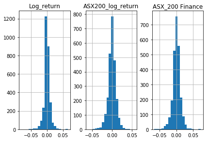

```python
#Plotting of histograms of entire ditributions

fig, axes = plt.subplots(1, 3)
fig.tight_layout()
DJIA.hist(column=['Log_return'],bins=20,ax=axes[0],figsize=(10,8))
plt.title('DJIA')
plt.savefig('DJIA_Log_return_distribution.png')

ASX_200.hist(column=['ASX200_log_return'],bins=20,ax=axes[1],figsize=(10,8))
plt.title('ASX_200')
plt.savefig('ASX_200_Log_return_distribution.png')

ASX_200_financials.hist(column=['ASX200_financial_Log_return'],bins=20,ax=axes[2],figsize=(10,8))
plt.title('ASX_200 Finance')
plt.savefig('ASX_200_Financial_Log_return_distribution.png')
plt.show()
```

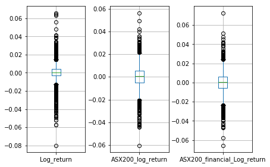

```python
fig, axes = plt.subplots(1, 3)
fig.tight_layout()

#Boxplots generated for overall distributions of all indexes volatilities
DJIA.boxplot(column=['Log_return'],ax=axes[0])
ASX_200.boxplot(column=['ASX200_log_return'],ax=axes[1])
ASX_200_financials.boxplot(column=['ASX200_financial_Log_return'],ax=axes[2])
plt.show()
```

```python
from scipy.stats import kurtosis, skew, shapiro
#Kurtosis tests
Kurtosis_DJIA=kurtosis(DJIA.Log_return.dropna())
Kurtosis_ASX_200=kurtosis(ASX_200.ASX200_log_return.dropna())
Kurtosis_ASX_200_financials=kurtosis(ASX_200_financials.ASX200_financial_Log_return.dropna())
#Skewness tests
Skew_DJIA=skew(DJIA.Log_return.dropna())
Skew_ASX_200=skew(ASX_200.ASX200_log_return.dropna())
Skew_ASX_200_financials=skew(ASX_200_financials.ASX200_financial_Log_return.dropna())
#Normality test using Shapiro-Wilks test
Normtest_DJIA=shapiro(DJIA.Log_return.dropna())
Normtest_ASX_200=shapiro(ASX_200.ASX200_log_return.dropna())
Normtest_ASX_200_financials=shapiro(ASX_200_financials.ASX200_financial_Log_return.dropna())
print('DJIA results\n')
print(f'Kurtosis and skew of DJIA are {Kurtosis_DJIA} and {Skew_DJIA} respectively')
print(f'Shapiro-Wilks normality test for DJIA data was {Normtest_DJIA}\n')
print('ASX 200 results\n')
print(f'Kurtosis and skew of ASX_200 are {Kurtosis_ASX_200} and {Skew_ASX_200} respectively')
print(f'Shapiro-Wilks normality test for ASX200 time series data was {Normtest_ASX_200}\n')
print('ASX 200 financials results\n')
print(f'Kurtosis and skew of ASX-200_financials are {Kurtosis_ASX_200_financials} and {Skew_ASX_200_financials} respectively')
print(f'Shapiro-Wilks normality test for ASX200 financials time series data was {Normtest_ASX_200_financials}\n')
```

```
DJIA results

Kurtosis and skew of DJIA are 8.356870304745875 and -0.4220576347027917 respectively
Shapiro-Wilks normality test for DJIA data was (0.8785310387611389, 4.119817485114962e-43)

ASX 200 results

Kurtosis and skew of ASX_200 are 2.9854214757981437 and -0.2863399727015251 respectively
Shapiro-Wilks normality test for ASX200 time series data was (0.9669922590255737, 1.1679865096371438e-23)

ASX 200 financials results

Kurtosis and skew of ASX-200_financials are 2.9672594507784895 and -0.1302569493560153 respectively
Shapiro-Wilks normality test for ASX200 financials time series data was (0.9680594801902771, 2.7172648357361565e-23)
```

### Grouping of index information using Group by and grouper functions.

- All indexs are grouped below by year
- Followed by that then the log returns the log return dsecriptive statistics are outputted in order to get the yearly volatility to see the distributions of the volatility per year.

```python
#Grouping data in all indexes by year
DJIA_by_year=DJIA.groupby(pd.Grouper(freq='Y'))
ASX_200_by_year=ASX_200.groupby(pd.Grouper(freq='Y'))
ASX_200_financials_by_year=ASX_200_financials.groupby(pd.Grouper(freq='Y'))
#Generating summary of annual variability
DJIA_yearly_volatility =DJIA_by_year.describe()
ASX_200_yearly_volatility =ASX_200_by_year.describe()
ASX_200_financials_yearly_volatility =ASX_200_financials_by_year.describe()
#Creating a new column to group data annually.
DJIA['Year']=DJIA.index.year
ASX_200['Year']=ASX_200.index.year
ASX_200_financials['Year']=ASX_200_financials.index.year
#Producing summary data results by year for log return for DJIA
```

### DJIA table of yearly Log return statistical summaries

```python
DJIA_yearly_volatility.Log_return
```

| Effective_date | count | mean | std | min | 25% | 50% | 75% | max |
| --- | --- | --- | --- | --- | --- | --- | --- | --- |
| 2008-12-31 | 61.0 | -0.000994 | 0.027450 | -0.080140 | -0.008226 | 0.000000 | 0.008032 | 0.064585 |
| 2009-12-31 | 365.0 | 0.000472 | 0.012661 | -0.047286 | -0.002666 | 0.000000 | 0.004940 | 0.066116 |
| 2010-12-31 | 365.0 | 0.000286 | 0.008459 | -0.036700 | -0.001258 | 0.000000 | 0.002280 | 0.038247 |
| 2011-12-31 | 365.0 | 0.000147 | 0.011030 | -0.057061 | -0.001930 | 0.000000 | 0.004314 | 0.041533 |
| 2012-12-31 | 309.0 | 0.000227 | 0.006679 | -0.023910 | -0.002606 | 0.000000 | 0.003030 | 0.023376 |
| 2013-12-31 | 252.0 | 0.000933 | 0.006399 | -0.023695 | -0.002812 | 0.001158 | 0.004750 | 0.023263 |
| 2014-12-31 | 252.0 | 0.000288 | 0.006861 | -0.020988 | -0.002621 | 0.000728 | 0.004230 | 0.023982 |
| 2015-12-31 | 252.0 | -0.000090 | 0.009736 | -0.036402 | -0.005244 | -0.000240 | 0.005801 | 0.038755 |
| 2016-12-31 | 252.0 | 0.000500 | 0.007951 | -0.034473 | -0.002845 | 0.000738 | 0.004311 | 0.024384 |
| 2017-12-31 | 251.0 | 0.000892 | 0.004172 | -0.017930 | -0.001404 | 0.000655 | 0.003055 | 0.014468 |
| 2018-12-31 | 213.0 | 0.000104 | 0.010171 | -0.047143 | -0.004340 | 0.000804 | 0.005465 | 0.028048 |

### ASX 200 table of Financials yearly Log return statistical summaries

```python
#Producing summary data results by year for log return for ASX 200 financial sector
ASX_200_financials_yearly_volatility.ASX200_financial_Log_return
```

| Effective_date | count | mean | std | min | 25% | 50% | 75% | max |
| --- | --- | --- | --- | --- | --- | --- | --- | --- |
| 2008-12-31 | 41.0 | -0.003255 | 0.027830 | -0.065650 | -0.023603 | -0.000856 | 0.011313 | 0.072735 |
| 2009-12-31 | 254.0 | 0.001173 | 0.016684 | -0.057695 | -0.009200 | 0.001202 | 0.011471 | 0.051393 |
| 2010-12-31 | 253.0 | -0.000381 | 0.011526 | -0.033965 | -0.008051 | -0.000542 | 0.006791 | 0.031941 |
| 2011-12-31 | 252.0 | -0.000438 | 0.012819 | -0.039862 | -0.007722 | 0.000288 | 0.007273 | 0.041643 |
| 2012-12-31 | 253.0 | 0.000776 | 0.007320 | -0.031586 | -0.003909 | 0.000861 | 0.005173 | 0.020701 |
| 2013-12-31 | 253.0 | 0.000838 | 0.008886 | -0.027355 | -0.004265 | 0.001206 | 0.006200 | 0.024872 |
| 2014-12-31 | 253.0 | 0.000248 | 0.007128 | -0.018558 | -0.004396 | 0.000890 | 0.005136 | 0.025093 |
| 2015-12-31 | 254.0 | 0.000026 | 0.011973 | -0.047154 | -0.006636 | 0.001192 | 0.006505 | 0.037836 |
| 2016-12-31 | 253.0 | 0.000161 | 0.011042 | -0.041994 | -0.006108 | 0.000892 | 0.005827 | 0.042102 |
| 2017-12-31 | 252.0 | -0.000017 | 0.007912 | -0.024295 | -0.005241 | 0.000547 | 0.004536 | 0.024079 |
| 2018-12-31 | 214.0 | -0.000595 | 0.008080 | -0.033692 | -0.005129 | -0.001348 | 0.004981 | 0.022491 |

### ASX 200 Index table of yearly Log return statistical summaries

```python
ASX_200_yearly_volatility.ASX200_log_return
```

| Effective_date | count | mean | std | min | 25% | 50% | 75% | max |
| --- | --- | --- | --- | --- | --- | --- | --- | --- |
| 2008-12-31 | 41.0 | -0.001864 | 0.026186 | -0.060363 | -0.016523 | -0.000393 | 0.013668 | 0.056271 |
| 2009-12-31 | 254.0 | 0.001059 | 0.013267 | -0.043635 | -0.006234 | 0.001187 | 0.010302 | 0.034106 |
| 2010-12-31 | 253.0 | -0.000103 | 0.009915 | -0.031707 | -0.006633 | 0.000478 | 0.006143 | 0.026227 |
| 2011-12-31 | 252.0 | -0.000622 | 0.012300 | -0.040839 | -0.007928 | -0.000192 | 0.006416 | 0.035870 |
| 2012-12-31 | 253.0 | 0.000539 | 0.007467 | -0.027050 | -0.003286 | 0.000534 | 0.005227 | 0.020915 |
| 2013-12-31 | 253.0 | 0.000557 | 0.007837 | -0.023540 | -0.003951 | 0.000816 | 0.005419 | 0.025925 |
| 2014-12-31 | 253.0 | 0.000043 | 0.007003 | -0.020684 | -0.004384 | 0.000429 | 0.004706 | 0.024243 |
| 2015-12-31 | 254.0 | -0.000085 | 0.010695 | -0.041769 | -0.005926 | 0.000437 | 0.006398 | 0.026824 |
| 2016-12-31 | 253.0 | 0.000267 | 0.009102 | -0.032233 | -0.005139 | 0.001002 | 0.005507 | 0.032864 |
| 2017-12-31 | 252.0 | 0.000270 | 0.005815 | -0.016744 | -0.002787 | 0.000528 | 0.003860 | 0.017323 |
| 2018-12-31 | 214.0 | -0.000169 | 0.006500 | -0.032532 | -0.003427 | 0.000114 | 0.004156 | 0.013344 |

### DJIA Boxplots generated on a yearly basis

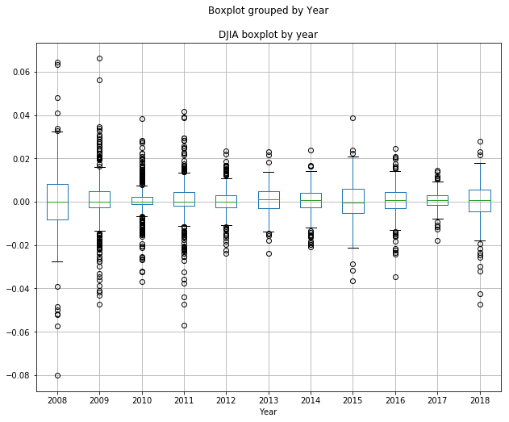

```python
#Generating box plot of time series data set to see the level of volatility from year to year.
fig,ax=plt.subplots(figsize=(10,8))

DJIA.boxplot(column=['Log_return'],by='Year',ax=ax)
plt.title('DJIA boxplot by year')
plt.savefig('DJIA_boxplot_by_year.png')
```

### ASX 200 Boxplots generated on a yearly basis

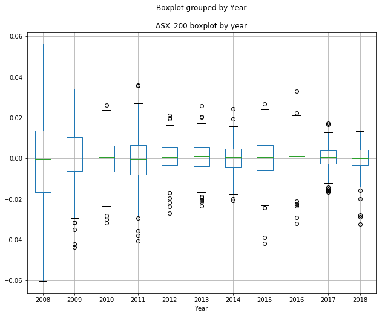

```python
#Generating box plot of time series data set to see the level of volatility from year to year.
fig,ax=plt.subplots(figsize=(10,8))

ASX_200.boxplot(column=['ASX200_log_return'],by='Year',ax=ax)
plt.title('ASX_200 boxplot by year')
plt.savefig('ASX_200_boxplot_by_year.png')
```

### ASX 200 Financials Boxplots generated on a yearly basis

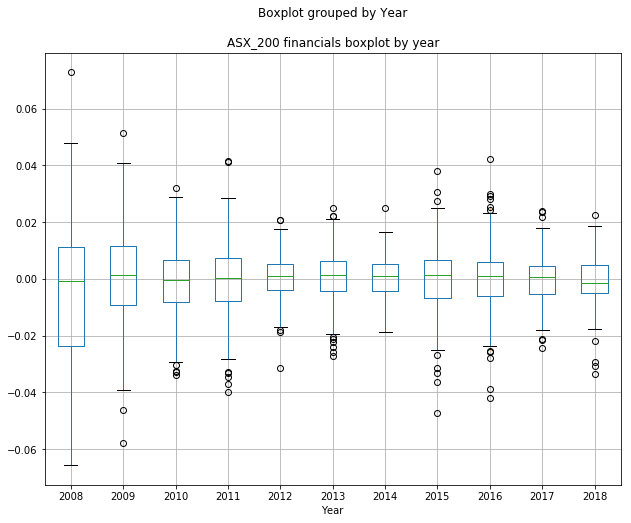

```python
#Generating box plot of time series data set to see the level of volatility from year to year.
fig,ax=plt.subplots(figsize=(10,8))

ASX_200_financials.boxplot(column=['ASX200_financial_Log_return'],by='Year',ax=ax)
plt.title('ASX_200 financials boxplot by year')
plt.savefig('ASX_200_boxplot_by_year.png')
```

### DJIA Histograms generated on a yearly basis

```
DJIA indexes histograms of volatility by year
```

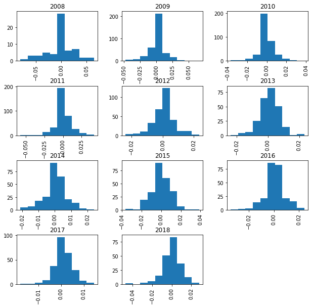

```python
print('DJIA indexes histograms of volatility by year')

DJIA['Log_return'].hist(by=DJIA['Year'],figsize=(10,10))

plt.show()
plt.savefig('DJIA_Hist_per_year.png')
```

### ASX200 Histograms generated on a yearly basis

```
ASX200 log returns Histograms by year
```

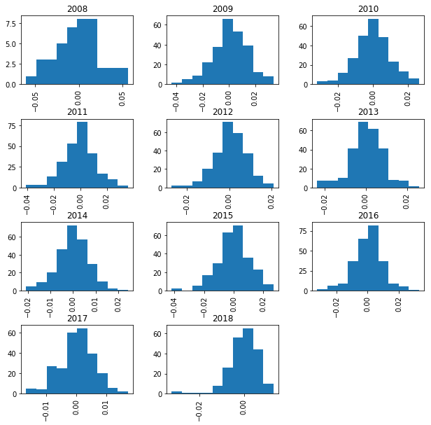

```python
print('ASX200 log returns Histograms by year')

ASX_200['ASX200_log_return'].hist(by=ASX_200['Year'],figsize=(10,10))

plt.show()

plt.savefig('ASX200_Hist_per_year.png')
```

### ASX200 financials Histograms generated on a yearly basis

```
ASX200 log returns Histograms by year
```

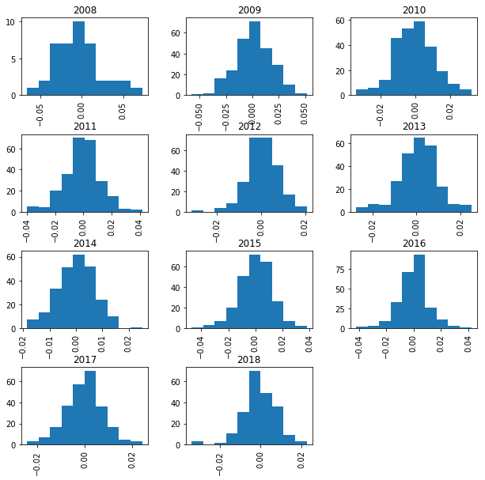

```python
print('ASX200 log returns Histograms by year')

ASX_200_financials['ASX200_financial_Log_return'].hist(by=ASX_200_financials['Year'],figsize=(10,10))

plt.show()
plt.savefig('ASX200_financials_Hist_per_year.png')
```

### Index yearly statistical summary

```python
#DJIA yearly normality, skewness and kurtosis assesssments
DJIA_yearly_normtest=DJIA_by_year.Log_return.apply(lambda x:shapiro(x))
DJIA_yearly_skewness=DJIA_by_year.Log_return.apply(lambda x:skew(x))
DJIA_yearly_kurtosis=DJIA_by_year.Log_return.apply(lambda x:kurtosis(x))

#ASX 200 yearly normality, skewness and kurtosis assesssments
ASX_200_yearly_normtest=ASX_200_by_year.ASX200_log_return.apply(lambda x:shapiro(x))
ASX_200_yearly_skewness=ASX_200_by_year.ASX200_log_return.apply(lambda x:skew(x))
ASX_200_yearly_kurtosis=ASX_200_by_year.ASX200_log_return.apply(lambda x:kurtosis(x))

ASX_200_financials_by_year
#ASX 200 yearly normality, skewness and kurtosis assesssments
ASX_200_financials_yearly_normtest=ASX_200_financials_by_year.ASX200_financial_Log_return.apply(lambda x:shapiro(x))
ASX_200_financials_yearly_skewness=ASX_200_financials_by_year.ASX200_financial_Log_return.apply(lambda x:skew(x))
ASX_200_financials_yearly_kurtosis=ASX_200_financials_by_year.ASX200_financial_Log_return.apply(lambda x:kurtosis(x))
```

```python
#DJIA RESULTS TABULATION#####
#Generating a table of the distribution statistics table along with a boolean to determine if the index annual distribution is
#non-normal
DJIA_year_dist_Stat=pd.concat([DJIA_yearly_kurtosis ,DJIA_yearly_skewness,DJIA_yearly_normtest],axis=1)#Concanating index dist stats into a single dataframe
DJIA_year_dist_Stat.columns=['kurtosis','skewness','normality test'] #Change dataframe column names
artemp=pd.DataFrame(DJIA_year_dist_Stat['normality test'].values.tolist(),index=DJIA_year_dist_Stat.index,columns=['Statistic number','P-value']) #split tuple dataframe of normality tests between p value and statistical results

#Reassigning shapiro wilks statistical results into separate columns in indexes annual stat summary dataframe
DJIA_year_dist_Stat['Statistic number']=artemp['Statistic number']
DJIA_year_dist_Stat['P-value']=artemp['P-value']
DJIA_year_dist_Stat.drop('normality test',axis=1,inplace=True)

#ASX 200 TABULATION########
#Generating a table of the distribution statistics table along with a boolean to determine if the index annual distribution is
#non-normal
ASX200_year_dist_Stat=pd.concat([ASX_200_yearly_kurtosis,ASX_200_yearly_skewness,ASX_200_yearly_normtest],axis=1)#Concanating index dist stats into a single dataframe
ASX200_year_dist_Stat.columns=['kurtosis','skewness','normality test'] #Change dataframe column names
artemp=pd.DataFrame(ASX200_year_dist_Stat['normality test'].values.tolist(),index=ASX200_year_dist_Stat.index,columns=['Statistic number','P-value']) #split tuple dataframe of normality tests between p value and statistical results

#Reassigning shapiro wilks statistical results into separate columns in indexes annual stat summary dataframe
ASX200_year_dist_Stat['Statistic number']=artemp['Statistic number']
ASX200_year_dist_Stat['P-value']=artemp['P-value']
ASX200_year_dist_Stat.drop('normality test',axis=1,inplace=True)

##ASX 200 FINANCIALS ##
#Generating a table of the distribution statistics table along with a boolean to determine if the index annual distribution is
#non-normal
ASX200fin_year_dist_Stat=pd.concat([ASX_200_financials_yearly_kurtosis ,ASX_200_financials_yearly_skewness,ASX_200_financials_yearly_normtest],axis=1)#Concanating index dist stats into a single dataframe
ASX200fin_year_dist_Stat.columns=['kurtosis','skewness','normality test'] #Change dataframe column names
artemp=pd.DataFrame(ASX200fin_year_dist_Stat['normality test'].values.tolist(),index=ASX200fin_year_dist_Stat.index,columns=['Statistic number','P-value']) #split tuple dataframe of normality tests between p value and statistical results

#Reassigning shapiro wilks statistical results into separate columns in indexes annual stat summary dataframe
ASX200fin_year_dist_Stat['Statistic number']=artemp['Statistic number']
ASX200fin_year_dist_Stat['P-value']=artemp['P-value']
ASX200fin_year_dist_Stat.drop('normality test',axis=1,inplace=True)

#Conditional to assess if annual results for distribution for index is normal or not based on shapiro wilks test.
DJIA_year_dist_Stat['Is the dist non-normal?']=DJIA_year_dist_Stat['P-value'].apply(stat_significant)
ASX200_year_dist_Stat['Is the dist non-normal?']=ASX200_year_dist_Stat['P-value'].apply(stat_significant)
ASX200fin_year_dist_Stat['Is the dist non-normal?']=ASX200_year_dist_Stat['P-value'].apply(stat_significant)
```

```python
print('DJIA index annual distribution information:\n')
DJIA_year_dist_Stat
```

```
DJIA index annual distribution information:
```

| Effective_date | kurtosis | skewness | Statistic number | P-value | Is the dist non-normal? |
| --- | --- | --- | --- | --- | --- |
| 2008-12-31 | NaN | NaN | NaN | 1.000000e+00 | False |
| 2009-12-31 | 4.406569 | 0.135900 | 0.888497 | 1.197797e-15 | True |
| 2010-12-31 | 4.367037 | -0.167505 | 0.860692 | 1.501862e-17 | True |
| 2011-12-31 | 4.946180 | -0.618890 | 0.875874 | 1.503649e-16 | True |
| 2012-12-31 | 1.789544 | 0.055055 | 0.952303 | 1.774197e-08 | True |
| 2013-12-31 | 1.310008 | -0.200644 | 0.984615 | 8.094166e-03 | True |
| 2014-12-31 | 1.105754 | -0.334760 | 0.974562 | 1.750413e-04 | True |
| 2015-12-31 | 1.431953 | -0.128368 | 0.983609 | 5.352859e-03 | True |
| 2016-12-31 | 2.120220 | -0.451998 | 0.959296 | 1.512057e-06 | True |
| 2017-12-31 | 2.286111 | -0.190952 | 0.969483 | 3.306046e-05 | True |
| 2018-12-31 | 3.436974 | -1.053384 | 0.938984 | 8.731151e-08 | True |

```python
print('ASX 200 index annual distribution information:\n')

ASX200_year_dist_Stat
```

```
ASX 200 index annual distribution information:
```

| Effective_date | kurtosis | skewness | Statistic number | P-value | Is the dist non-normal? |
| --- | --- | --- | --- | --- | --- |
| 2008-12-31 | NaN | NaN | NaN | 1.000000e+00 | False |
| 2009-12-31 | 0.539535 | -0.296056 | 0.990077 | 8.064588e-02 | False |
| 2010-12-31 | 0.375421 | -0.130011 | 0.992831 | 2.625556e-01 | False |
| 2011-12-31 | 0.680031 | -0.099946 | 0.990966 | 1.219308e-01 | False |
| 2012-12-31 | 0.905792 | -0.348232 | 0.986568 | 1.798844e-02 | True |
| 2013-12-31 | 0.777512 | -0.198108 | 0.986490 | 1.740066e-02 | True |
| 2014-12-31 | 0.525756 | -0.108164 | 0.993455 | 3.358787e-01 | False |
| 2015-12-31 | 0.874807 | -0.368461 | 0.986584 | 1.773580e-02 | True |
| 2016-12-31 | 1.155385 | -0.243682 | 0.985571 | 1.178834e-02 | True |
| 2017-12-31 | 0.350519 | -0.226424 | 0.990971 | 1.221672e-01 | False |
| 2018-12-31 | 4.873260 | -1.375453 | 0.917323 | 1.455439e-09 | True |

```python
print('ASX200 financials index annual distribution information:\n')
ASX200fin_year_dist_Stat
```

[output not shown]

## Time series Normality, kurtosis and Skew tests summary results

### Results over indices entire distribution.

All indices are non normal

DJIA

- high kurtosis (>8)
- partial negative skewness(<-0.4).

ASX200

ASX200_fin partial negative skewness(<-0.13).

### Results over annual distributions analysis

#### ASX200 / ASX200 financials

[1]Mele, Antonio. "Asymmetric stock market volatility and the cyclical behavior of expected returns." Journal of financial economics 86.2 (2007): 446-478.

[2]Andersen, T. G., Bollerslev, T., Diebold, F. X. and Ebens, H. (2001a), The distribution of realized stock return volatility, Journal of Financial Economics 61(1), 43–76.

### Autocorrelation performed on an annual basis for all indexes

-The purpose of this assessment was to find a lookback window between historical volatility and future volatility.

### Time series EDA summary

[1]Sewell, Martin. "Characterization of financial time series." RN 11, no. 01 2011: 01.

```python
DJIA_yearly_groups=DJIA_by_year.groups #Getting the groups of each index and assigning them to group variables to use them as dictionaries.
ASX_200_yearly_groups=ASX_200_by_year.groups
ASX_200_financial_yearly_groups=ASX_200_financials_by_year.groups

DJIA_year_key_ar=list(DJIA_yearly_groups.keys())
ASX_200_year_key_ar=list(ASX_200_yearly_groups.keys())
ASX_200_financial_year_key_ar=list(ASX_200_financial_yearly_groups.keys())
Combo_index_list=[DJIA_year_key_ar,ASX_200_year_key_ar,ASX_200_financial_year_key_ar]

lags=[1,3,10,30] #,40,100,120] additional lag values hashed out for posterity

index_name='DJIA-'

for index_year in DJIA_year_key_ar: #Iterating each year in variable index_year_keys for DJIA

    temp=DJIA_by_year.get_group(index_year) #Get group function used to pull the specific year specified by for loop
    temp_log_return=temp.Log_return
    str_yr=str(index_year)
    for lag in lags: #iterate through the different lag values in the for loop specified in the lags list and produce ACF plots as a result.
        plot_acf(temp_log_return,lags=lag,title=index_name+str_yr[0:4]+'-lag-'+str(lag))
```

[output not shown]

```python
#ASX-200 Autocorrelation plots can be found below.

index_name='ASX-200-'

for index_year in ASX_200_year_key_ar: #Iterating each year in variable index_year_keys for DJIA

    temp=ASX_200_by_year.get_group(index_year) #Get group function used to pull the specific year specified by for loop
    temp_log_return=temp.ASX200_log_return
    str_yr=str(index_year)
    for lag in lags: #iterate through the different lag values in the for loop specified in the lags list and produce ACF plots as a result.
        plot_acf(temp_log_return,lags=lag,title=index_name+str_yr[0:4]+'-lag-'+str(lag))
```

[output not shown]

```python
#ASX-200 Autocorrelation plots can be found below.

index_name='ASX-200_financials-'

for index_year in ASX_200_financial_year_key_ar: #Iterating each year in variable index_year_keys for DJIA

    temp=ASX_200_financials_by_year.get_group(index_year) #Get group function used to pull the specific year specified by for loop
    temp_log_return=temp.ASX200_financial_Log_return
    str_yr=str(index_year)
    for lag in lags: #iterate through the different lag values in the for loop specified in the lags list and produce ACF plots as a result.
        plot_acf(temp_log_return,lags=lag,title=index_name+str_yr[0:4]+'-lag-'+str(lag))
```

[output not shown]

# Exploratory Data analysis of news text dataset and data set up

## Exploratory Data analysis

Initial analysis of the text data set consisted of assessing document length (See figures below). From this it can be seen that this data set consists of short text messages similar to microblog text data. As a result initially an LDA topic model was initially selected for the topic modelling of this data set as it has historically been shown to be successful at analysing short text datasets like Twitter [6].

As part of the investigation into using NMF term correlation matrix an estimate of the ratio of rarely used words to the total text corpus to the total vocabulary of the text corpus was performed also.

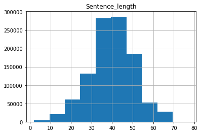

```python
#Exploratory data analysis count the total number of unique words and character length


Text_data['Sentence_length'] = Text_data['headline_text'].map(str).apply(len)

Text_data.hist(column='Sentence_length')
plt.savefig('Sentence_length_histogram.png')
```

```python
#Exploratory data analysis count the total number of unique words and character length

count_string= Text_data.headline_text.tolist() #Converting list to dataframe for analysis.
count_string2=[]

for vals in count_string: #Splitting each string into corresponding components for counting
    ar_string=0
    ar_string=vals.split()

    for drvals in ar_string: #Iterating through each word in string and appending to list for further processing.

        count_string2.append(drvals)

Gross_no_of_words=len(count_string2) #Determint the total number of words in the text corpus

vocab_dictionary={} #Create a dictionary to store counts of unique values in

for valz in count_string2:  #Iterating through gross no of words and determining total number of each unique word
    if valz in vocab_dictionary:
        vocab_dictionary[valz]+=1
    else:
        vocab_dictionary[valz]=1

vocab_dictionary_non_rare = dict((k, v) for k, v in vocab_dictionary.items() if v >= 5) #Create a dictionary for all non rare vocab that occurs more than 5 times

No_of_unique_non_rare_terms=len(vocab_dictionary_non_rare.keys()) #Determine number of non rare terms in text corpus

List_of_unique_words=set(count_string2)
No_of_unique_words_stpwrds_included=len(List_of_unique_words) #Determine the total number of unique words in the corpus
print(f'total number of words in text corpus:{len(count_string2)}')
print(f'total number of unique words in text corpus rare words removed:{No_of_unique_non_rare_terms}')
print(f'total number of unique words in text corpus rare words included:{No_of_unique_words_stpwrds_included}')
```

```
total number of words in text corpus:6634897
total number of unique words in text corpus rare words removed:36048
total number of unique words in text corpus rare words included:102533
```

## OOP Objects for text preprocessing and topic modelling:

The breakdown of the different programs that are used in this analysis are as follows:

- Text tokenisation, lemmatisation and stop word removal
- Data Aggregation objects
- NMF model objects

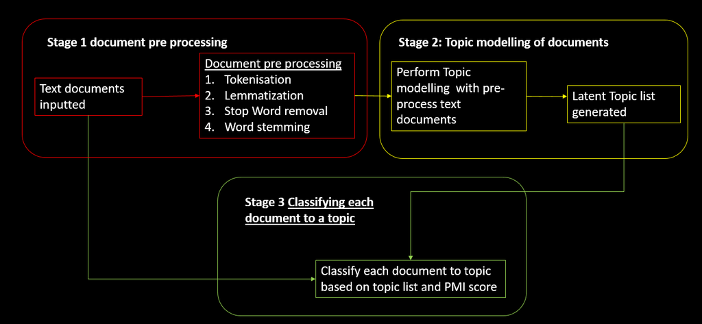

```python
from IPython.display import Image
Image(filename='PFD_text_processing.png')
```

```python
from IPython.display import Image
from IPython.core.display import HTML

PATH = r"/C:/Users/aczd087/MyDocs/Data science masters/IN3061 INM430 Prin of Data Sc/Coursework"
Image(filename = PATH + "PFD_text_processing.png", width=100, height=100)
```

```python
from spacy.lang.en import English #importing english language varient of spacy for extraction of tokens from text data
parser = English()
def tokenize(text): #Tokenizing function which converts input 'text' string to spacy doc string list lda_tokens
    fin_tokens = [] #blank variable where final important token words from string text will be returned as the final string list
    tokens = parser(text) #converting text string to spacy doc doc
    for token in tokens: #for loop iterating through words in string text input
        if token.orth_.isspace(): #if space is found in text string ignore and continue for loop
            continue
        elif token.like_url: #function handle for recording url
            fin_tokens.append('URL')
        elif token.orth_.startswith('@'): #fundction handle for recording screen names of users
            fin_tokens.append('SCREEN_NAME')
        else:
            fin_tokens.append(token.lower_) #final else statement for recording all words in string into lda_tokens
    return fin_tokens
```

```python
nltk.download('wordnet')#Downloading lemmisation dictionary wordnet from nltk
from nltk.corpus import wordnet as wn
def get_lemma(word): #Lemmatisation function which returns lemmatisation of word if present i.e. if trying reduce to try etc.
    lemma = wn.morphy(word) #Determine is lemmatisation is present if it is return the lemmatisation of the word.
    if lemma is None:
        return word
    else:
        return lemma
```

```python
#Lematisation and tokenisation function to convert news headlines strings
def tokenising(text): #applies def tokenize object program to the entire dataframe
    tokens = tokenize(text) #Tokenize function called to convert string to list of words

    tokens = [token for token in tokens if token not in en_stop] # List comp Filter out any stopword tokens

    return tokens

def lemmatisation(text): #applies def get_lemma program to entire dataframe
    tokens = [get_lemma(token) for token in tokens] # List comp Lematize all tokens present in the text string

    return tokens

def prepare_text_for_lda(text): #Tokenisation model used for LDA

    #applies function objects def tokenizing and def lemmatize to entire topic dataframe in series

    tokens = tokenize(text)
    tokens = [token for token in tokens if len(token) > 4]
    tokens = [token for token in tokens if token not in en_stop]
    tokens = [get_lemma(token) for token in tokens]
    return tokens


def convert_text_lemma_df(Text_df):

    '''
    funtion converts text dataframe of headlines to lemmatised tokenized dataframe of headlines instead with stopwords removed also.
    '''

    Token_list=[] #initialising blank list for storing lemmatised text

    for idx, vals in Text_df.headline_text.iteritems(): #iterating through headline text and performing tokenisation and lemmitisation and storing in list
        temp=0
        temp=prepare_text_for_lda(vals)
        Token_list.append(temp)

    Token_flat_list =[]  #list where flattened out nested lists from initial tokenisation will be stored.

    for sublist in Token_list: #iterating through nest list from initial for loop joining nested list strings together and then outputting single headline strings for ch headline to be stored in flatted list
        temp=0
        temp=str(" ".join(sublist))

        Token_flat_list.append(temp)

    proc_df=pd.DataFrame(Token_flat_list) #convert flattened out list to dataframe
    proc_df.columns=['headline_text'] #add dataframe heading

    return proc_df #return dataframe.
```

```python
#Creation of Bigrams and Trigrams for LDA modelling

# Build the bigram and trigram models
def make_bigrams(texts):
    return [bigram_mod[doc] for doc in texts]#List comprehension to generate bigrams from text using bigram gensim model defined above

def make_trigrams(texts):
    return [trigram_mod[bigram_mod[doc]] for doc in texts] #List comprehension to generate trigrams from text using bigram gensim model defined above
```

```python
#print out LDA topics into a data frame for manual coherence check

def get_lda_topics(model, num_topics): #Print lda topic as dataframe for manual analysis
    word_dict = {}; #Initialising dictionary for storing topics for model

    for i in range(num_topics): #For loop to iterate through number of topics
        words = model.show_topic(i, topn = 20);
        word_dict['Topic # ' + '{:02d}'.format(i+1)] = [i[0] for i in words];
    return pd.DataFrame(word_dict); #Conversoin of model to dataframe.
```

```python
#Conversion of strings in dataframe to tokenised version using gesim simpleprocess function

def sent_to_words(sentences): #short version of LDA preprocessing provided all gensim library is functioning.
    for sentence in sentences:
        yield(gensim.utils.simple_preprocess(str(sentence), deacc=True))  # deacc=True removes punctuations

def iter_token_lemmatisation(final_list,df_column):
    #Purpose of object is to iterate through the dataframe and lematise and tokenize each value and append into a list

    for index, row in df_column.iteritems():

        tokens = prepare_text_for_lda(row) #Iterating through each headline and performing lemmatisation and tokenising of the data set
        final_list.append(tokens) #Appending tokenised and lemmatised data to list in the form of a list variable

    return final_list
```

### Data aggregation objects

```python
#Merging of text datasets on the same date index

def merge_text_rows(df,df_col,df_index): #Converts single column dataframe containing text merges all text rows based on date index

    test_merge=df.groupby([df_index])[df_col].apply(lambda x:'. '.join(x.astype(str)))
    test_frame=pd.DataFrame({df_col:test_merge},index=test_merge.index)
    return test_frame
```

```python
def assign_BSH_label_to_text(df_BSH,df_no_of_topics_per_day,df_text,column_name):


    df_BSH_list=df_BSH.tolist() #Conversion of dataframe to lists
    df_no_of_topics_per_day_list=df_no_of_topics_per_day.tolist()

    temp_array=[]
    flat_list=[]

    for vals,multi in zip(df_BSH_list,df_no_of_topics_per_day_list): #iterating through dataframe please not zip function will always stop at the lower limit of the two sets
        temp_array2=[]
        temp_array2=[vals]
        temp_array.append(temp_array2*multi) #Expanding size of list by number of headlines assigned to it for that day

    for sublist in temp_array: #Flattening nest list for conversion to dataframe

        for item in sublist:

            flat_list.append(item)

    index_size=len(flat_list) #Determine how long dataframe index has to be

    trn=np.array(flat_list)

    BSH_index=df_text.index

    BSH_series=pd.DataFrame(np.array(flat_list),columns=[column_name],)

    df_text=df_text.reset_index(drop=True) #Resetting and removing old indexes for concatanation of two dataframes
    BSH_series=BSH_series.reset_index()

    str_reg='index'

    if str_reg in df_text.columns:
        df_text.drop(['index'],axis=1,inplace=True)
    elif str_reg in BSH_series.columns:
        BSH_series.drop(['index'],axis=1,inplace=True)
    else:
        pass

    df_final=pd.concat([df_text,BSH_series],axis=1) #Please not join is left join by index by default
    df_final.head()
    return df_final
```

### NMF model objects and classes:

Please note that the objects referenced here are object versions of Python scripts written by a researcher Dr.Tian Shi who is a pHD researcher at Virginia Tech. The link below to his original work can be found her :

https://github.com/tshi04/SeaNMF

```python
#Functions to be utilised in NMP analysis


#Please note as well for these scripts to be utilised file directories and empty text files need to be generated for storing the following files:

#- Text_file
#- Corpus_file
#- Vocab_file
#- Results files W.txt,Wc,txt and H.txt which are used to store the final topic model results and the topic model itself.

#A short description of what each object does can be found in the readme file

#Please note also the following:

#The maximum text file size that can be processed with 8GB of RAM  is <1800kB and that the average processing time for this file size with a modelling iterations setpoint of 100 is in excess of 1hour.


def read_docs(file_name):
    print('read documents')
    print('-'*50)
    docs = []
    fp = open(file_name, 'r')
    for line in fp:
        arr = re.split('\s', line[:-1])
        arr = filter(None, arr)
        arr = [int(idx) for idx in arr]
        docs.append(arr)
    fp.close()

    return docs

def read_vocab(file_name):
    print('read vocabulary')
    print('-'*50)
    vocab = []
    fp = open(file_name, 'r')
    for line in fp:
        arr = re.split('\s', line[:-1])
        vocab.append(arr[0])
    fp.close()

    return vocab

def calculate_PMI(AA, topKeywordsIndex):
    '''
    Reference:
    Short and Sparse Text Topic Modeling via Self-Aggregation
    '''
    D1 = np.sum(AA)
    n_tp = len(topKeywordsIndex)
    PMI = []
    for index1 in topKeywordsIndex:
        for index2 in topKeywordsIndex:
            if index2 < index1:
                if AA[index1, index2] == 0:
                    PMI.append(0.0)
                else:
                    C1 = np.sum(AA[index1])
                    C2 = np.sum(AA[index2])
                    PMI.append(np.log(AA[index1,index2]*D1/C1/C2))
    avg_PMI = 2.0*np.sum(PMI)/float(n_tp)/(float(n_tp)-1.0)

    return avg_PMI
```

```python
'''
Short Text Topic Modeling via SeaNMF
'''
class SeaNMFL1(object):
    def __init__(
        self,
        A, S,
        IW1=[], IW2=[], IH=[],
        alpha=1.0, beta=0.1, n_topic=10, max_iter=100, max_err=1e-3,
        rand_init=True, fix_seed=False):
        '''
        0.5*||A-WH^T||_F^2+0.5*alpha*||S-WW_c^T||_F^2+0.5*beta*||W||_1^2
        W = W1
        Wc = W2
        '''
        if fix_seed:
            np.random.seed(0)

        self.A = A
        self.S = S

        self.n_row = A.shape[0]
        self.n_col = A.shape[1]

        self.n_topic = n_topic
        self.max_iter = max_iter
        self.alpha = alpha
        self.beta = beta
        self.B = np.ones([self.n_topic,1])
        self.max_err = max_err

        if rand_init:
            self.nmf_init_rand()
        else:
            self.nmf_init(IW1, IW2, IH)
        self.nmf_iter()

    def nmf_init_rand(self):
        self.W1 = np.random.random((self.n_row, self.n_topic))
        self.W2 = np.random.random((self.n_row, self.n_topic))
        self.H = np.random.random((self.n_col, self.n_topic))

        for k in range(self.n_topic):
            self.W1[:, k] /= norm(self.W1[:, k])
            self.W2[:, k] /= norm(self.W2[:, k])

    def nmf_init(self, IW1, IW2, IH):
        self.W1 = IW1
        self.W2 = IW2
        self.H = IH

        for k in range(self.n_topic):
            self.W1[:, k] /= norm(self.W1[:, k])
            self.W2[:, k] /= norm(self.W2[:, k])

    def nmf_iter(self):
        loss_old = 1e20
        print('loop begin')
        start_time = time.time()
        for i in range(self.max_iter):
            self.nmf_solver()
            loss = self.nmf_loss()
            if loss_old-loss < self.max_err:
                break
            loss_old = loss
            end_time = time.time()
            print('Step={}, Loss={}, Time={}s'.format(i, loss, end_time-start_time))

    def nmf_solver(self):
        '''
        using BCD framework
        '''
        epss = 1e-20
        # Update W1
        AH = np.dot(self.A, self.H)
        SW2 = np.dot(self.S, self.W2)
        HtH = np.dot(self.H.T, self.H)
        W2tW2 = np.dot(self.W2.T, self.W2)
        W11 = self.W1.dot(self.B)

        for k in range(self.n_topic):
            num0 = HtH[k,k]*self.W1[:,k] + self.alpha*W2tW2[k,k]*self.W1[:,k]
            num1 = AH[:,k] + self.alpha*SW2[:,k]
            num2 = np.dot(self.W1, HtH[:,k]) + self.alpha*np.dot(self.W1, W2tW2[:,k]) + self.beta*W11[0]
            self.W1[:,k] = num0 + num1 - num2
            self.W1[:,k] = np.maximum(self.W1[:,k], epss) # project > 0
            self.W1[:,k] /= norm(self.W1[:,k]) + epss # normalize
        # Update W2
        W1tW1 = self.W1.T.dot(self.W1)
        StW1 = np.dot(self.S, self.W1)
        for k in range(self.n_topic):
            self.W2[:,k] = self.W2[:,k] + StW1[:,k] - np.dot(self.W2, W1tW1[:,k])
            self.W2[:,k] = np.maximum(self.W2[:,k], epss)
        #Update H
        AtW1 = np.dot(self.A.T, self.W1)
        for k in range(self.n_topic):
            self.H[:,k] = self.H[:,k] + AtW1[:,k] - np.dot(self.H, W1tW1[:,k])
            self.H[:,k] = np.maximum(self.H[:,k], epss)

    def nmf_loss(self):
        '''
        Calculate loss
        '''
        loss = norm(self.A - np.dot(self.W1, np.transpose(self.H)), 'fro')**2/2.0
        if self.alpha > 0:
            loss += self.alpha*norm(np.dot(self.W1, np.transpose(self.W2))-self.S, 'fro')**2/2.0
        if self.beta > 0:
            loss += self.beta*norm(self.W1, 1)**2/2.0

        return loss

    def get_lowrank_matrix(self):
        return self.W1, self.W2, self.H

    def save_format(self, W1file='W.txt', W2file='Wc.txt', Hfile='H.txt'):
        np.savetxt(W1file, self.W1)
        np.savetxt(W2file, self.W2)
        np.savetxt(Hfile, self.H)

'''
Topic Modeling via NMF
'''
class NMF(object):
    def __init__(
        self,
        A, IW=[], IH=[],
        n_topic=10, max_iter=100, max_err=1e-3,
        rand_init=True):
        '''
        A = WH^T
        '''
        self.A = A
        self.n_row = A.shape[0]
        self.n_col = A.shape[1]

        self.n_topic = n_topic
        self.max_iter = max_iter
        self.max_err = max_err

        self.obj = []
        if rand_init:
            self.nmf_init_rand()
        else:
            self.nmf_init(IW, IH)
        self.nmf_iter()

    def nmf_init_rand(self):
        self.W = np.random.random((self.n_row, self.n_topic))
        self.H = np.random.random((self.n_col, self.n_topic))

        for k in range(self.n_topic):
            self.W[:,k] /= norm(self.W[:,k])

    def nmf_init(self, IW, IH):
        self.W = IW
        self.H = IH

        for k in range(self.n_topic):
            self.W[:,k] /= norm(self.W[:,k])

    def nmf_iter(self):
        loss_old = 1e20
        print('loop begin')
        start_time = time.time()
        for i in range(self.max_iter):
            self.nmf_solver()
            loss = self.nmf_loss()
            self.obj.append(loss)

            if loss_old-loss < self.max_err:
                break
            loss_old = loss
            end_time = time.time()
            print('Step={}, Loss={}, Time={}s'.format(i, loss, end_time-start_time))
        print('loop end')

    def nmf_solver(self):
        '''
        regular NMF without constraint.
        Block Coordinate Decent
        '''
        epss = 1e-20

        HtH = self.H.T.dot(self.H)
        AH = self.A.dot(self.H)
        for k in range(self.n_topic):
            tmpW = self.W[:,k]*HtH[k,k] + AH[:,k] - np.dot(self.W, HtH[:,k])
            self.W[:,k] = np.maximum(tmpW, epss)
            self.W[:,k] /= norm(self.W[:,k]) + epss

        WtW = self.W.T.dot(self.W)
        AtW = self.A.T.dot(self.W)
        for k in range(self.n_topic):
            self.H[:,k] = self.H[:,k]*WtW[k,k] + AtW[:,k] - np.dot(self.H, WtW[:,k])
            self.H[:,k] = np.maximum(self.H[:,k], epss)

    def nmf_loss(self):
        loss = norm(self.A - np.dot(self.W, np.transpose(self.H)), 'fro')**2/2.0
        return loss

    def get_loss(self):
        return np.array(self.obj)

    def get_lowrank_matrix(self):
        return self.W, self.H

    def save_format(self, Wfile='W.txt', Hfile='H.txt'):
        np.savetxt(Wfile, self.W)
        np.savetxt(Hfile, self.H)
```

```python
def NMF_Pre_process(text_file_loc,corpus_file_loc,vocab_file_loc,vocab_max_size):

    '''
    Visualize Topics
    '''
    #parser = argparse.ArgumentParser()
    #parser.add_argument('--text_file', default='data/data.txt', help='input text file')
    #parser.add_argument('--corpus_file', default='data/doc_term_mat.txt', help='term document matrix file')
    #parser.add_argument('--vocab_file', default='data/vocab.txt', help='vocab file')
    #parser.add_argument('--vocab_max_size', type=int, default=10000, help='maximum vocabulary size')
    #parser.add_argument('--vocab_min_count', type=int, default=3, help='minimum frequency of the words')
    #args = parser.parse_args()

    args=easydict.EasyDict({'text_file':text_file_loc,#'data/2009_jan2Jun_abc_news_text_lemma_notepad.txt', #Parameters that are inputted into thte model prior to starting processing
                            'corpus_file':corpus_file_loc,#'data/doc_term_mat_abcnews.txt',
                            'vocab_file':vocab_file_loc,#'data/vocab.txt',
                            'vocab_max_size':vocab_max_size,#10000,
                            'vocab_min_count':3
                            })

    # create vocabulary
    print('create vocab')
    vocab = {}
    fp = open(args.text_file, 'r')
    for line in fp:
        arr = re.split('\s', line[:-1])
        for wd in arr:
            try:
                vocab[wd] += 1
            except:
                vocab[wd] = 1 #Creating complete vocabulary list
    fp.close()
    vocab_arr = [[wd, vocab[wd]] for wd in vocab if vocab[wd] > args.vocab_min_count] #Creating a dictionary from text file
    vocab_arr = sorted(vocab_arr, key=lambda k: k[1])[::-1]
    vocab_arr = vocab_arr[:args.vocab_max_size]
    vocab_arr = sorted(vocab_arr)

    fout = open(args.vocab_file, 'w') #writing dictionary to vocab text file
    for itm in vocab_arr:
        itm[1] = str(itm[1])
        fout.write(' '.join(itm)+'\n')
    fout.close()

    # vocabulary to id
    vocab2id = {itm[1][0]: itm[0] for itm in enumerate(vocab_arr)}
    print('create document term matrix')
    data_arr = []
    fp = open(args.text_file, 'r') #Opens up text file and is generating a document term matrix
    fout = open(args.corpus_file, 'w')
    for line in fp:
        arr = re.split('\s', line[:-1])
        arr = [str(vocab2id[wd]) for wd in arr if wd in vocab2id]
        sen = ' '.join(arr)
        fout.write(sen+'\n')
    fp.close()
    fout.close()
```

```python
def NMF_training_model(corpus_file_loc,vocab_file_loc,max_iter,n_topics):

    '''
    SeaNMF Training
    '''


    #parser = argparse.ArgumentParser()
    #parser.add_argument('--corpus_file', default='data/doc_term_mat.txt', help='term document matrix file')
    #parser.add_argument('--vocab_file', default='data/vocab.txt', help='vocab file')
    #parser.add_argument('--model', default='seanmf', help='nmf | seanmf')
    #parser.add_argument('--max_iter', type=int, default=500, help='max number of iterations')
    #parser.add_argument('--n_topics', type=int, default=100, help='number of topics')
    #parser.add_argument('--alpha', type=float, default=0.1, help='alpha')
    #parser.add_argument('--beta', type=float, default=0.0, help='beta')
    #parser.add_argument('--max_err', type=float, default=0.1, help='stop criterion')
    #parser.add_argument('--fix_seed', type=bool, default=True, help='set random seed 0')
    #args = parser.parse_args()

    args=easydict.EasyDict({'corpus_file':corpus_file_loc, #'data/doc_term_mat_abcnews.txt', #Loading model attributes into a single file
                            'vocab_file':vocab_file_loc,#'data/vocab.txt',
                            'model':'seanmf',
                            'max_iter':max_iter,#100,
                            'n_topics':n_topics,#300,
                            'alpha':0.1,
                            'beta':0.0,
                            'max_err':0.1,
                            'fix_seed':True
                            })

    docs = read_docs(args.corpus_file) #Reading in text corpus file
    vocab = read_vocab(args.vocab_file) #Reading in vocabulary file
    n_docs = len(docs) #Determining the total number of documents
    n_terms = len(vocab) #Determining the total number of terms
    print('n_docs={}, n_terms={}'.format(n_docs, n_terms))

    tmp_folder = 'seanmf_results'
    if not os.access(tmp_folder, os.F_OK): #accesining folder seanmf_results to store final results in text format in
        os.mkdir(tmp_folder)

    if args.model.lower() == 'nmf':
        print('read term doc matrix')
        dt_mat = np.zeros([n_terms, n_docs]) #initialising empty term document matrix to be filled during processing
        for k in range(n_docs):
            for j in docs[k]: # filling counts of each word in term document matrix
                dt_mat[j, k] += 1.0
        print('term doc matrix done')
        print('-'*50)

        model = NMF( #generating NMF model with parameters term document matrix, max error, max number of toics and max number of iterations
            dt_mat,
            n_topic=args.n_topics,
            max_iter=args.max_iter,
            max_err=args.max_err)

        model.save_format( #Save model in temporary folder
            Wfile=tmp_folder+'/W.txt',
            Hfile=tmp_folder+'/H.txt')

    if args.model.lower() == 'seanmf': #Generate co-occurance matrix
        print('calculate co-occurance matrix')
        dt_mat = np.zeros([n_terms, n_terms]) #generate empty co-occurence to store data into.
        for itm in docs:
            for kk in itm:
                for jj in itm:
                    dt_mat[int(kk),int(jj)] += 1.0 #Adding value each time cooccurence is denoted between words
        print('co-occur done')
        print('-'*50)
        print('calculate PPMI')
        D1 = np.sum(dt_mat) #PMI value calculated between words in topic to determine the give an indicator of cooccurence of these values
        SS = D1*dt_mat
        for k in range(n_terms):
            SS[k] /= np.sum(dt_mat[k])
        for k in range(n_terms):
            SS[:,k] /= np.sum(dt_mat[:,k])
        dt_mat = [] # release memory
        SS[SS==0] = 1.0
        SS = np.log(SS)
        SS[SS<0.0] = 0.0
        print('PPMI done')
        print('-'*50)

        print('read term doc matrix') #Size of term document matrix primary cause for memory error please ensure text corpus<1800kB
        dt_mat = np.zeros([n_terms, n_docs])
        for k in range(n_docs):
            for j in docs[k]: #Fill in term document matrix into a numpy array
                dt_mat[j, k] += 1.0
        print('term doc matrix done')
        print('-'*50)

        model = SeaNMFL1(
            dt_mat, SS,
            alpha=args.alpha,
            beta=args.beta,
            n_topic=args.n_topics,
            max_iter=args.max_iter,
            max_err=args.max_err,
            fix_seed=args.fix_seed)

        model.save_format(
            W1file=tmp_folder+'/W.txt',
            W2file=tmp_folder+'/Wc.txt',
            Hfile=tmp_folder+'/H.txt')
```

```python
def NMF_Printout_topics(corpus_file_loc,vocab_file_loc,par_file_loc,results_file_name):

    '''
    Visualize Topics
    '''

    #parser = argparse.ArgumentParser()
    #parser.add_argument('--corpus_file', default='data/doc_term_mat.txt', help='term document matrix file')
    #parser.add_argument('--vocab_file', default='data/vocab.txt', help='vocab file')
    #parser.add_argument('--par_file', default='seanmf_results/W.txt', help='model results file')
    #opt = parser.parse_args()

    opt=easydict.EasyDict({'corpus_file':corpus_file_loc,#'data/doc_term_mat_abcnews.txt',
                            'vocab_file':vocab_file_loc,#'data/vocab.txt',
                            'par_file':par_file_loc,#'seanmf_results/W.txt',
                            })

    docs = read_docs(opt.corpus_file)
    vocab = read_vocab(opt.vocab_file)
    n_docs = len(docs)
    n_terms = len(vocab)
    print('n_docs={}, n_terms={}'.format(n_docs, n_terms))

    dt_mat = np.zeros([n_terms, n_terms])
    for itm in docs:
        for kk in itm:
            for jj in itm:
                if kk != jj:
                    dt_mat[int(kk), int(jj)] += 1.0
    print('co-occur done')

    W = np.loadtxt(opt.par_file, dtype=float)
    n_topic = W.shape[1]
    print('n_topic={}'.format(n_topic))

    PMI_arr = []
    n_topKeyword = 10
    for k in range(n_topic):
        topKeywordsIndex = W[:,k].argsort()[::-1][:n_topKeyword]
        PMI_arr.append(calculate_PMI(dt_mat, topKeywordsIndex))
    print('Average PMI={}'.format(np.average(np.array(PMI_arr))))

    index = np.argsort(PMI_arr)

    for k in index:
        print('Topic ' + str(k+1) + ': ', end=' ')
        Topic_temp=k+1
        print(PMI_arr[k], end=' ')
        PMI_temp=PMI_arr[k]

        for w in np.argsort(W[:,k])[::-1][:n_topKeyword]:
            print(vocab[w], end=' ')
        print()

    block=pd.DataFrame([]) #initialsing empty
    val_temp=[]
    PMI_temp=[]
    Topic_temp=[]

    for k in index:

        Topic_temp.append(k+1) #add 1 to value of topic number for acccuracy

        PMI_temp.append(PMI_arr[k])# append PMI values to list

        ar_temp=[] # initialise temporary list vocabulary to for each topic

        for w in np.argsort(W[:,k])[::-1][:n_topKeyword]: #iterating through each topic word
            ar_temp.append(vocab[w]) #appending each word in topic to list

        ar_join= ' '.join(ar_temp) #joining all separate words of topic into a single string

        val_temp.append(ar_join) #appending final completed string into topic list

    block =block.append(pd.DataFrame({'Topic_No':Topic_temp,'PMI_value':PMI_temp,'Topic_string':val_temp}),ignore_index=True) #appending completed topic into a dataframe row

    block.to_excel(results_file_name)
```

## Text downsampling and feature labelling

Please find below the text sub sampling that was performed in order to perform the text analysis. Sub sampling was performed between the following dates:

- 2008 to 2011
- 2011 to 2014
- 2009 01-Jan to 30-Jun
- 2012 01-Jan to 30-Jun
- 2014 01-Jan to 30-Jun

All data sets where labelled up with the appropriated buy,sell and hold labels that was completed in the prior section also for processing during the modeling stage.

```python
#Intial Subselecting a sample of news data to perform textual analysis
start_date_2008='2008-10-31'
end_date_2011='2011-10-31'

start_date_2011='2011-10-31'
end_date_2014='2014-10-31'

#Date Mask created applied to delinated data between different dates of headline subsampling points

mask_2008_2011=(Text_data['Date'] > start_date_2008) & (Text_data['Date'] <= end_date_2011)

mask_2009_jan_to_jun=(Text_data['Date'] >= start_date_2009) & (Text_data['Date'] <= end_jun_date_2009)

mask_2012_jan_to_jun=(Text_data['Date'] >= start_date_2012) & (Text_data['Date'] <= end_jun_date_2012)

mask_2014_jan_to_jun=(Text_data['Date'] >= start_date_2014) & (Text_data['Date'] <= end_jun_date_2014)

mask_2011_2014=(Text_data['Date'] > start_date_2011) & (Text_data['Date'] <= end_date_2014)

#Appling date masks to sub sample text headline data from news headline data set
News_2009_jan_jun=Text_data.loc[mask_2009_jan_to_jun]
News_2009_jan_jun['Date']=pd.to_datetime(News_2009_jan_jun['Date'])


News_2012_jan_jun=Text_data.loc[mask_2012_jan_to_jun]
News_2012_jan_jun['Date']=pd.to_datetime(News_2012_jan_jun['Date'])


News_2014_jan_jun=Text_data.loc[mask_2014_jan_to_jun]
News_2014_jan_jun['Date']=pd.to_datetime(News_2014_jan_jun['Date'])

News_2008_to_2011=Text_data.loc[mask_2008_2011]

News_2011_to_2014=Text_data.loc[mask_2011_2014]

#Merged dataframe for merged data analysis
News_2008_2011_merge=merge_text_rows(News_2008_to_2011,'headline_text','Date')
News_2011_2014_merge=merge_text_rows(News_2011_to_2014,'headline_text','Date')
```

```python
#Count the number of headlines per day for each dataframe and loc into specific years time frames

No_of_headlines_per_day_pt1=Text_data.groupby([Text_data.Date.dt.date]).agg('count')

No_of_headlines_per_day=pd.DataFrame(No_of_headlines_per_day_pt1['headline_text'])
No_of_headlines_per_day.index=pd.to_datetime(No_of_headlines_per_day.index)

#No of headlines 2009

No_of_headlines2009_per_day_janjun=No_of_headlines_per_day.loc[startdateDT_2009_janjun:enddateDT_2009_janjun]

#No of headlines 2012

No_of_headlines2012_per_day_janjun=No_of_headlines_per_day.loc[startdateDT_2012_janjun:enddateDT_2012_janjun]

#No of headlines 2014

No_of_headlines2014_per_day_janjun=No_of_headlines_per_day.loc[startdateDT_2014_janjun:enddateDT_2014_janjun]
```

```python
#Assigning buy sell hold labels to News datasets for different indexes
DJIA_BSH_col_name='DJIA_BuySellHoldLabels'
ASX_200_BSH_col_name='ASX_200_BuySellHoldLabels'
ASX_200_Fin_BSH_col_name='ASX_200_Fin_BSHLabels'
```

```python
#Labelling of buy,sell and hold all data for 2009 period
#DJIA
News_2009_jan_jun=assign_BSH_label_to_text(DJIA_2009janjun.buy_sell_hold_label,
                                           No_of_headlines2009_per_day_janjun.headline_text,
                                           News_2009_jan_jun,
                                           DJIA_BSH_col_name)

#ASX 200
News_2009_jan_jun=assign_BSH_label_to_text(ASX_200_2009janjun.buy_sell_hold_label,
                                           No_of_headlines2009_per_day_janjun.headline_text,
                                           News_2009_jan_jun,
                                           ASX_200_BSH_col_name)
#ASX_200 financials
News_2009_jan_jun=assign_BSH_label_to_text(ASX_200_fin_2009janjun.buy_sell_hold_label,
                                           No_of_headlines2009_per_day_janjun.headline_text,
                                           News_2009_jan_jun,
                                           ASX_200_Fin_BSH_col_name)

#Labelling of buy sell hold for all data for 2012 period
#DJIA
News_2012_jan_jun=assign_BSH_label_to_text(DJIA_2012janjun.buy_sell_hold_label,
                                           No_of_headlines2012_per_day_janjun.headline_text,
                                           News_2012_jan_jun,
                                           DJIA_BSH_col_name)

#ASX_200
News_2012_jan_jun=assign_BSH_label_to_text(ASX_200_2012janjun.buy_sell_hold_label,
                                           No_of_headlines2012_per_day_janjun.headline_text,
                                           News_2012_jan_jun,
                                           ASX_200_BSH_col_name)

#ASX_200 financials
News_2012_jan_jun=assign_BSH_label_to_text(ASX_200_fin_2012janjun.buy_sell_hold_label,
                                           No_of_headlines2012_per_day_janjun.headline_text,
                                           News_2012_jan_jun,
                                           ASX_200_Fin_BSH_col_name)

#labelling of buy sell hold for all data in 2014
#DJIA
News_2014_jan_jun=assign_BSH_label_to_text(DJIA_2014janjun.buy_sell_hold_label,
                                           No_of_headlines2014_per_day_janjun.headline_text,
                                           News_2014_jan_jun,
                                           DJIA_BSH_col_name)

#ASX 200
News_2014_jan_jun=assign_BSH_label_to_text(ASX_200_2014janjun.buy_sell_hold_label,
                                           No_of_headlines2014_per_day_janjun.headline_text,
                                           News_2014_jan_jun,
                                           ASX_200_BSH_col_name)

#ASX_200 financials
News_2014_jan_jun=assign_BSH_label_to_text(ASX_200_fin_2014janjun.buy_sell_hold_label,
                                           No_of_headlines2014_per_day_janjun.headline_text,
                                           News_2014_jan_jun,
                                           ASX_200_Fin_BSH_col_name)
```

```python
#Assign News headlines from Jan-Jun for 2009, 2012 and 2014 to separate dataframes

#Token_list=News_2009_jan_jun_list
#Text_df=News_2009_jan_jun
#Token_flat_list=News_2009_jan_jun_list_flat
```

```python
#Converting of janjun dataframe 2009 to lemmatised version for storage in excel spread and text format to be carried forward for NMF processing.
News_2009_janjun_proc_df=convert_text_lemma_df(News_2009_jan_jun)

#Conversion to text file for NMF processing
News_2009_janjun_proc_df.to_excel('News_2009_janjun_proc_df.xlsx')

#Printing head of dataset
News_2009_janjun_proc_df.head()
```

```python
#Converting of janjun dataframe 2012 to lemmatised version for storage in excel spread and text format to be carried forward for NMF processing.
News_2012_janjun_proc_df=convert_text_lemma_df(News_2012_jan_jun)

#Conversion to text file for NMF processing
News_2012_janjun_proc_df.to_excel('News_2012_janjun_proc_df.xlsx')

#Printing head of dataset
News_2012_janjun_proc_df.head()
```

```python
#Converting of janjun dataframe 2014 to lemmatised version for storage in excel spread and text format to be carried forward for NMF processing.
News_2014_janjun_proc_df=convert_text_lemma_df(News_2014_jan_jun)

#Conversion to text file for NMF processing
News_2014_janjun_proc_df.to_excel('News_2014_janjun_proc_df.xlsx')

#Printing head of dataset
News_2014_janjun_proc_df.head()
```

## NMF and LDA topic modelling data pre processing tokenisation, lemmitisation etc

Data wrangling of data set prior to performing any analysis.

```python
#Lemmatisation and tokensiation of 2008 to 2014 data sets please note that this take will take approximatly 10 minutes to complete.
News_2008_2011_text_data = [] #List to store all tokenised and lemmatised values in dataset
News_2011_2014_text_data = []


for index, row in News_2008_to_2011.headline_text.iteritems():
    tokens =prepare_text_for_lda(row) #Iterating through each headline and performing lemmatisation and tokenising of the data set
    News_2008_2011_text_data.append(tokens) #Appending tokenised and lemmatised data to list in the form of a list variable

for index, row in News_2011_to_2014.headline_text.iteritems():
    tokens = prepare_text_for_lda(row) #Iterating through each headline and performing lemmatisation and tokenising of the data set
    News_2011_2014_text_data.append(tokens)#Appending tokenised and lemmatised data to list in the form of a list variable

bigram = gensim.models.Phrases(News_2008_2011_text_data, min_count=5, threshold=100) # higher threshold fewer phrases.
trigram = gensim.models.Phrases(bigram[News_2008_2011_text_data], threshold=100)

bigram_mod = gensim.models.phrases.Phraser(bigram)
trigram_mod = gensim.models.phrases.Phraser(trigram)
```

```python
#Lemmatisation and tokensiation of entire data sets please note that this take will take approximatly 10 minutes to complete.

News_preproc_full_data_set=[]

for index, row in Text_data.headline_text.iteritems():
    tokens = lemmatisation_and_tokenising(row) #Iterating through each headline and performing lemmatisation and tokenising of the data set
    News_preproc_full_data_set.append(tokens) #Appending tokenised and lemmatised data to list in the form of a list variable
```

```python
#New_2009_jan_jun=[]

News_2009_jan_jun_raw=News_2009_jan_jun.headline_text.tolist()

New_2009_jan_jun_list=prepare_text_for_lda(News_2009_jan_jun_raw)
```

```python
#Iterating through merged dataframe of News text information from 2008 to 2014 based on dates and tokenising/lemmitisation

News_2008_to_2011_merge_preproc=[] #Initialising list for storing dataframe.
News_2011_to_2014_merge_preproc=[]

News_2008_to_2011_merge_preproc=iter_token_lemmatisation(News_2008_to_2011_merge_preproc,News_2008_2011_merge.headline_text)

News_2011_to_2014_merge_preproc=iter_token_lemmatisation(News_2011_to_2014_merge_preproc,News_2011_2014_merge.headline_text)
```

## LDA topic modelling

LDA Topic modelling of this nature was applied over the following time intervals:

- 2008 to 2011

The initial range of topics where set between 25 and 50 for the time period from 2008 to 2011. The topic range was based on historical topic modelling of news articles [1]. All of the models topics generated where assessed on semantic coherence the following criteria:

1. Manual Human User assessment for semantic coherence of the document topics
2. Semantic coherence testing using CV semantic topic coherence which has been found to be correlate best in the literature with qualitative human interpretation of semantic topic coherence[2]

1. Increasing the number of topics up to a maximum of 400. This was done so as a stop check just to confirm the incoherent vague topics was not as a result of not enough topics being specified which is another typical problem that can be encountered with LDA topic modelling[3].
2. The headline document text corpus was aggregated by date to increase the text corpus size (which is suggested in the literature as way to overcome this issue [4]).
3. Changing the dictionary from a ‘Bag of Words’ dictionary to TF-IDF dictionary to remove infrequent or very frequent keywords for the topic modelling. This was done to reduce down the overall text sparsity in the term document matrix by reducing the overall size of the text corpus.

- [1]W. Jacobi, “Quantitative analysis of large amounts of journalistic texts using topic modelling,” Digital Journalism, vol. 4, no. 1, pp. 89-106, 2016.
- [2]Michael Röder, “Exploring the Space of Topic Coherence Measures,” in Proceedings of the eighth ACM international conference on Web search and data mining. , New York, 2015.
- [3]Chae, J., Thom, D., Bosch, H., Jang, Y., Maciejewski, R., Ebert, D.S. and Ertl, T., 2012, October. Spatiotemporal social media analytics for abnormal event detection and examination using seasonal-trend decomposition. In Visual Analytics Science and Technology (VAST), 2012 IEEE Conference on (pp. 143-152). IEEE.
- [4]B. D. D. Liangjie Hong, “Empirical Study of Topic Modeling in Twitter,” in Proceedings of the first workshop on social media analytics ACM., 2010.
- [5]W. Yan Xiaohui, “Learning Topics in Short Texts by Non-negative Matrix Factorization on term correlation matrix,” in Proceedings of the 2013 SIAM International Conference on Data Mining, Austin Texas, 2013.

```python
#Load final LDA model results and print out plot of LDA models with respect to topic size for human qualititative analysise versus CV score
os.chdir(r'\\nsq024vs\u8\aczd087\MyDocs\Data science masters\IN3061 INM430 Prin of Data Sc\Coursework\results')

LDA_summary=pd.read_excel('LDA summary results.xlsx')
```

```python
LDA_summary
```

|  | LDA model No | TD-IDF filtering applied | Data aggregation by date used | No of topics | Human coherence score on 20 topics | C_v coherence score |
| --- | --- | --- | --- | --- | --- | --- |
| 0 | 1 | No | No | 25 | 0.32 | 0.51 |
| 1 | 2 | Yes | No | 25 | 0.32 | 0.51 |
| 2 | 3 | No | No | 50 | 0.40 | 0.55 |
| 3 | 4 | No | Yes | 50 | 0.54 | 0.29 |
| 4 | 5 | Yes | Yes | 50 | 0.52 | 0.29 |
| 5 | 6 | No | No | 75 | 0.36 | 0.55 |
| 6 | 7 | No | No | 100 | 0.32 | 0.59 |
| 7 | 8 | No | No | 400 | 0.28 | NaN |

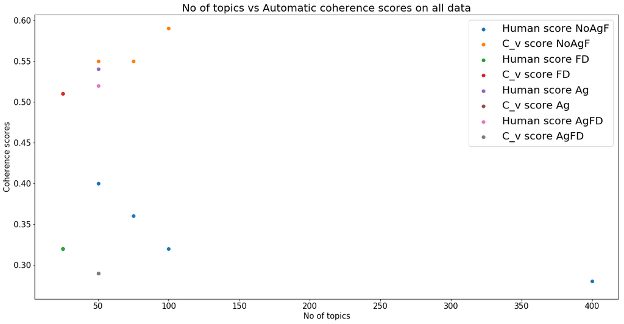

```python
#Plot coherence scores for analysis
import warnings
warnings.filterwarnings('ignore')

params = {'legend.fontsize': 20,
          'legend.handlelength': 2}

plt.rcParams.update(params)

LDAsummary_noForAg=LDA_summary.loc[(LDA_summary['TD-IDF filtering applied']=='No') &
                                   (LDA_summary['Data aggregation by date used']=='No')]


fig, ax = plt.subplots(figsize=(20,10))
ax.scatter(LDAsummary_noForAg['No of topics'], LDAsummary_noForAg['Human coherence score on 20 topics'])

#plt.scatter(x=LDAsummary_noForAg['No of topics'],
 #           y=LDAsummary_noForAg['Human coherence score on 20 topics'])

#plt.scatter(x=LDAsummary_noForAg['No of topics'],
 #           y=LDAsummary_noForAg['C_v coherence score'])

ax.scatter(LDAsummary_noForAg['No of topics'], LDAsummary_noForAg['C_v coherence score'])

#Data filtered data point
ax.scatter(LDA_summary.iloc[1,3],
            LDA_summary.iloc[1,4])

ax.scatter(LDA_summary.iloc[1,3],
            LDA_summary.iloc[1,5])

#Data aggregation data point
ax.scatter(LDA_summary.iloc[3,3],
            LDA_summary.iloc[3,4])

ax.scatter(LDA_summary.iloc[3,3],
            LDA_summary.iloc[3,5])


#Data aggregation and filtered data point
ax.scatter(LDA_summary.iloc[4,3],
            LDA_summary.iloc[4,4])

ax.scatter(LDA_summary.iloc[4,3],
            LDA_summary.iloc[4,5])
ax.set_xlabel('No of topics',fontsize=15)
ax.set_ylabel('Coherence scores',fontsize=15)

ax.tick_params(labelsize=15)

mylabels=['Human score NoAgF','C_v score NoAgF',
          'Human score FD','C_v score FD',
          'Human score Ag','C_v score Ag',
          'Human score AgFD','C_v score AgFD',]
ax.legend(labels=mylabels,fontsize=20)
plt.title('No of topics vs Automatic coherence scores on all data',fontsize=20)
#plt.savefig('Human_coh_vs_CV_coh_alldata.png')

plt.show()
```

[output not shown]

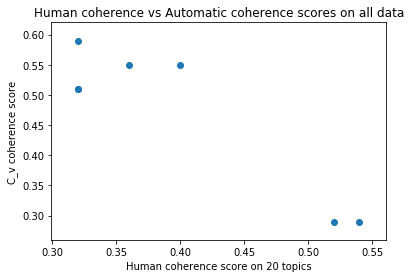

```python
plt.scatter(x=LDA_summary['Human coherence score on 20 topics'],
            y=LDA_summary['C_v coherence score'])

plt.xlabel('Human coherence score on 20 topics')
plt.ylabel('C_v coherence score')
plt.title('Human coherence vs Automatic coherence scores on all data')
#plt.savefig('Human_coh_vs_CV_coh_all_data_pts.png')
```

### LDA topic modelling 2008 to 2011 and 2011 to 2014 with merged and filtered datasets

```python
#LDA topic modelling analysis performance
#Initial generation of dictionary is performed with entire headlines text as opposed to specific timeframes so equivalent bag-of-words
#are present for assessing each model
from gensim import corpora
dictionary = corpora.Dictionary(News_preproc_full_data_set) #Create a dictionary from text data
corpus = [dictionary.doc2bow(text) for text in News_preproc_full_data_set]

pickle.dump(corpus, open('corpus_abc_news.pkl', 'wb'))

dictionary.save('dictionary_corpus_abc_news.gensim')
```

```python
#LDA topic modelling analysis performance
#Topic modelling of news corpus from 2008 to 2011
from gensim import corpora
dictionary_2008_2011= corpora.Dictionary(News_2008_2011_text_data) #Create a dictionary from text data
corpus_2008_2011 = [dictionary_2008_2011.doc2bow(text) for text in News_2008_2011_text_data]
```

```python
#LDA topic modelling analysis performance
#Topic modelling of news corpus from 2008 to 2011 saving models
pickle.dump(corpus, open('corpus_abc_news.pkl_2008_2011', 'wb'))

dictionary_2008_2011.save('dictionary_corp_abc_news_2008_2011.gensim')
```

```python
#LDA topic modelling analysis performance
#Topic modelling of news corpus from 2011 to 2014
dictionary_2011_2014= corpora.Dictionary(News_2011_2014_text_data) #Create a dictionary from text data
corpus_2011_2014 = [dictionary_2011_2014.doc2bow(text) for text in News_2011_2014_text_data]
```

```python
#LDA topic modelling analysis performance
#Topic modelling of news corpus from 2011 to 2014  saving models

pickle.dump(corpus, open('corpus_abc_news.pkl_2011_2014', 'wb'))

dictionary_2011_2014.save('dictionary_corp_abc_news_2011_2014.gensim')
```

```python
#LDA topic with 25 topics modelling analysis performance from 2008 to 2011
NUM_TOPICS = 25
ldamodel_2008_2011 = gensim.models.ldamodel.LdaModel(corpus_2008_2011, num_topics = NUM_TOPICS, id2word=dictionary_2008_2011, passes=15)
#ldamodel_2008_2011.save('model25_2008_2011.gensim')
#topics_2008_2011 = ldamodel_2008_2011.print_topics(num_words=4)
```

```python
#Reload pickle file from 2008 to 2011
os.chdir(r'\\nsq024vs\u8\aczd087\MyDocs\Data science masters\IN3061 INM430 Prin of Data Sc\Coursework\Gensim models of LDA\models\2008 to 2011')

ldamodel_2008_2011=gensim.models.LdaModel.load('model25_2008_2011.gensim')
```

```python
#Generate coherence score for model

#DUE TO A GENSIM BUG PLEASE NOTE THE MODEL NEEDS TO BE REGENERATED PRIOR TO RUNNING THE COHERENCE SCORE ESTIMATE THE A LOADED MODEL CANNOT BE USED

coherence_model_lda_2008_2011_25topics = CoherenceModel(model=ldamodel_2008_2011, texts=News_2008_2011_text_data, dictionary=dictionary_2008_2011, coherence='c_v')
coherence_lda_2008_2011_25 = coherence_model_lda_2008_2011_25topics.get_coherence()
print('\nCoherence Score: ', coherence_lda_2008_2011_25)
```

```python
coherence_model_lda_2008_2011_25topics.get_coherence()
```

```python
#Model2008to2011_25topicslist=Model2008to2011_25topics.show_topics(num_topics=25, num_words=15, log=False, formatted=True)

print('topic list 2008 to 2011 25 topics:\n')
Model2008to2011_25topicsdf=get_lda_topics(Model2008to2011_25topics,25)

Model2008to2011_25topicsdf.to_excel('Model2008to2011_25topicsdf.xlsx')

Model2008to2011_25topicsdf
```

```python
#Filtering tokens in document state to try and improve coherence
dictionary_2008_2011.filter_extremes(no_below=15,no_above=0.5,keep_n=100000)
corpus_2008_2011_filter = [dictionary_2008_2011.doc2bow(text) for text in News_2008_2011_text_data]
NUM_TOPICS = 25
ldamodel_2008_2011_filter = gensim.models.ldamodel.LdaModel(corpus_2008_2011_filter, num_topics = NUM_TOPICS, id2word=dictionary_2008_2011, passes=15)
```

```python
#Output model topics for LDA TD-IDF model
Model2008to2011_25topicsdffiltered=get_lda_topics(ldamodel_2008_2011_filter,25)

Model2008to2011_25topicsdf.to_excel('Model2008to2011_25topicsfiltereddf.xlsx')
```

```python
print('topic list 2008 to 2011 25 filtered topics:\n')
Model2008to2011_25topicsdffiltered
```

```
topic list 2008 to 2011 25 filtered topics:
```

|  | Topic # 01 | Topic # 02 | Topic # 03 | Topic # 04 | Topic # 05 | Topic # 06 | Topic # 07 | Topic # 08 | Topic # 09 | Topic # 10 | ... | Topic # 16 | Topic # 17 | Topic # 18 | Topic # 19 | Topic # 20 | Topic # 21 | Topic # 22 | Topic # 23 | Topic # 24 | Topic # 25 |
| --- | --- | --- | --- | --- | --- | --- | --- | --- | --- | --- | --- | --- | --- | --- | --- | --- | --- | --- | --- | --- | --- |
| 0 | industry | court | found | charge | police | hospital | accused | carbon | claim | interview | ... | council | plan | round | death | north | flood | fear | sydney | worker | australia |
| 1 | government | child | hearing | attack | health | business | beyond | williams | protest | talks | ... | qantas | search | power | arrest | burn | coast | kill | urge | fight | world |
| 2 | seek | mining | guilty | murder | victim | award | sport | mayor | occupy | take | ... | change | break | house | return | south | highlight | aussie | resident | wallaby | assault |
| 3 | tourism | feature | politics | league | still | canberra | group | trial | force | indigenous | ... | deny | record | call | final | question | young | spark | cause | rural | medium |
| 4 | boost | stun | season | unite | protester | australian | national | tribute | defend | could | ... | times | condition | union | probe | student | digger | review | operator | make | tourist |
| 5 | strike | perth | wounded | harvest | open | bash | uncertainty | family | face | opposition | ... | funds | winemaker | sales | jail | safety | going | scores | irrigators | cancer | warn |
| 6 | rule | public | plead | station | sign | budget | back | future | gillard | fire | ... | project | wimmera | storm | predict | relieve | postpone | disappoint | consider | announce | first |
| 7 | doubt | suspension | debate | demand | friday | housing | threat | community | warwick | former | ... | visit | state | melbourne | gaddafi | greens | winery | driver | shooting | robbery | wilkie |
| 8 | clear | labor | libya | adelaide | mental | introduce | action | hunter | stab | teacher | ... | ahead | injure | blaze | pass | begin | england | premier | newcastle | quarter | appeal |
| 9 | youth | queensland | shark | coach | lanka | virgin | reveal | blues | abbott | title | ... | inquest | study | crime | japan | escape | rally | start | investigate | beach | river |
| 10 | election | hawke | numbers | another | bull | export | challenge | decision | flight | injury | ... | climate | china | doctor | village | scientist | country | black | forum | brawl | target |
| 11 | promise | grower | bring | remains | phone | speak | forest | shire | party | pakistan | ... | detention | street | threaten | want | fraud | horse | present | airport | head | move |
| 12 | obama | island | strong | building | christmas | analysis | court | highway | company | worry | ... | plant | emergency | research | three | disaster | match | train | campaign | figure | lose |
| 13 | leaf | second | arrive | problem | attempt | services | rebel | scheme | defence | india | ... | tough | damage | victory | abuse | catch | hotel | clash | prepare | leave | expect |
| 14 | apple | quake | roads | drop | pledge | light | legal | allege | solar | people | ... | issue | closure | name | years | fruit | point | fine | expert | unveil | policy |
| 15 | protection | hendra | behind | sheep | syrian | development | launch | green | security | blast | ... | jackson | focus | clean | early | explosion | david | brisbane | libyan | struggle | federal |
| 16 | tackle | hear | surgery | traffic | racing | festival | million | eagle | dollar | soldier | ... | chogm | drive | falls | queen | ambulance | quit | afghan | theft | scandal | truck |
| 17 | father | interest | upgrade | criticise | elderly | drug | pressure | stand | outback | warrior | ... | killing | show | increase | rates | property | crackdown | darwin | double | board | refugee |
| 18 | chinese | facing | bronco | angry | creek | extend | gunns | cyclone | tasmanian | stosur | ... | michael | level | thousand | tip | crow | davis | parliament | producer | test | office |
| 19 | political | animal | fishing | human | survivor | slam | heritage | discus | contract | profit | ... | shake | lockyer | sugar | british | look | compo | bomber | cancel | arm | flooding |

20 rows × 25 columns

```python
#Coherence modelling of 2008 to 2011 filtered model.
#due to a gensim bug PLEASE NOTE THAT MODEL HSA TO BE GENERATED FROM SCRATCH TO GET THIS SCORE THE LOADED UP MODEL CANNOT BEUSED TO GET THIS SCORE
coherence_model_lda_2008_2011_25topics_filter = CoherenceModel(model= ldamodel_2008_2011_filter, texts=News_2008_2011_text_data, dictionary=dictionary_2008_2011, coherence='c_v')
coherence_lda_2008_2011score_25Filter = coherence_model_lda_2008_2011_25topics_filter.get_coherence()
print('\nCoherence Score: ', coherence_lda_2008_2011score_25Filter)
```

### LDA topic model with 50 topics hyperparameter selection 2008 to 2011

```python
#LDA topic with 50 topics modelling analysis performance from 2008 to 2011
NUM_TOPICS = 50
ldamodel_2008_2011_50topics  = gensim.models.ldamodel.LdaModel(corpus_2008_2011, num_topics = NUM_TOPICS, id2word=dictionary_2008_2011, passes=15)
```

```python
#LDA topic with 50 topics modelling analysis performance from 2008 to 2011
ldamodel_2008_2011_50topics.save('model50_2008_2011.gensim')

topics_2008_2011_50_top = ldamodel_2008_2011_50topics.print_topics()
for topic in topics_2008_2011_50_top:
    print(topic)
```

```python
#Reload pickle file from 2008 to 2011
os.chdir(r'\\nsq024vs\u8\aczd087\MyDocs\Data science masters\IN3061 INM430 Prin of Data Sc\Coursework\Gensim models of LDA\models\2008 to 2011')

ldamodel_2008_2011_50topics=gensim.models.LdaModel.load('model50_2008_2011.gensim')
```

```python
print('topic list 2008 to 2011 50 topics:\n')
Model2008to2011_50topicsdf=get_lda_topics(ldamodel_2008_2011_50topics,25)

Model2008to2011_50topicsdf.to_excel('Model2008to2011_50topicsdf.xlsx')

Model2008to2011_50topicsdf
```

```
topic list 2008 to 2011 50 topics:
```

|  | Topic # 01 | Topic # 02 | Topic # 03 | Topic # 04 | Topic # 05 | Topic # 06 | Topic # 07 | Topic # 08 | Topic # 09 | Topic # 10 | ... | Topic # 16 | Topic # 17 | Topic # 18 | Topic # 19 | Topic # 20 | Topic # 21 | Topic # 22 | Topic # 23 | Topic # 24 | Topic # 25 |
| --- | --- | --- | --- | --- | --- | --- | --- | --- | --- | --- | --- | --- | --- | --- | --- | --- | --- | --- | --- | --- | --- |
| 0 | hit | get | attack | wine | report | business | cattle | fear | plan | flood | ... | driver | win | 's | market | take | council | call | qantas | face | house |
| 1 | farmer | australian | aussie | centre | industry | wa | 2 | car | carbon | shot | ... | young | cup | williams | mine | news | beyond | probe | top | court | push |
| 2 | deny | price | queensland | final | deal | protest | introduce | ' | change | dead | ... | hope | medium | claim | test | award | set | future | end | nt | cut |
| 3 | want | rise | hawke | group | tourism | row | decision | die | seek | league | ... | may | good | funding | wounded | high | dairy | turkish | job | feature | delay |
| 4 | minister | mp | join | sales | harvest | budget | town | make | fight | coal | ... | dog | close | scores | start | digger | sign | matilda | lose | national | cause |
| 5 | release | flow | hunter | new | station | uncertainty | years | sport | politics | stun | ... | village | case | break | relieve | bob | threat | plane | police | clash | warning |
| 6 | sky | greens | former | green | export | support | turn | move | tietze | asylum | ... | 600 | improve | reinvigorate | black | year | waltz | site | allege | race | rule |
| 7 | run | worldview | use | nz | tigers | slip | announce | family | vote | 3 | ... | dollar | housing | three | airport | fall | name | injury | boat | visit | protester |
| 8 | telling | rail | plant | pm | flight | head | sri | community | debate | w | ... | jackson | bid | study | impact | cat | project | police | youth | clear | blaze |
| 9 | week | boss | victory | food | risk | analysis | bali | afl | ahead | seeker | ... | leaders | teen | policy | bomb | speed | meet | right | hunt | party | crop |
| 10 | bail | welcome | million | sale | look | play | sea | crash | highway | fly | ... | afghanistan | drum | rape | link | five | debt | tough | rock | wo | rally |
| 11 | grain | seam | nurse | light | defence | royal | lanka | accident | climate | president | ... | wrap | wallaby | violence | afghan | resume | new | discus | prepare | abuse | detention |
| 12 | dispute | animal | chase | queen | kohler | cancer | praise | riot | security | parliament | ... | taxi | title | pilot | stay | political | focus | son | png | regional | bomber |
| 13 | london | chopper | admit | ship | street | bring | johnson | closure | old | expert | ... | past | development | great | early | honour | grant | survey | robbery | campaign | sell |
| 14 | thousand | program | nod | brawl | research | nrl | hard | police | quarter | libyan | ... | marriage | men | pie | trade | merger | scientist | crew | meeting | pressure | long |
| 15 | sheep | transport | series | form | care | southern | hub | tree | expansion | energy | ... | august | legal | foreign | wall | raider | best | mouse | knife | takeover | oil |
| 16 | nuclear | new | bike | ride | control | councillor | lawyer | marine | syrian | 11 | ... | clarke | truck | approval | fraud | remember | woe | comment | arm | poky | issue |
| 17 | refuse | producer | edge | poll | increase | rising | benefit | investigation | wool | gay | ... | approve | loom | israel | draw | surge | killer | ash | board | v | tackle |
| 18 | fund | bligh | pool | outbreak | better | declare | days | mix | roll | reach | ... | stoush | david | late | facing | hail | pledge | mum | field | liberal | hurt |
| 19 | robber | details | hobart | sink | plea | 1 | insurance | debut | new | france | ... | watson | flooding | smash | reform | allegation | snowy | factory | watch | given | suicide |

20 rows × 25 columns

```python
#LDA topic with 50 topics modelling analysis performance from 2008 to 2011
#due to a gensim bug PLEASE NOTE THAT MODEL HAS TO BE GENERATED FROM SCRATCH TO GET THIS SCORE THE LOADED UP MODEL CANNOT BEUSED TO GET THIS SCORE

#Topic Coherence measurements
from gensim.models.coherencemodel import CoherenceModel
# Compute Coherence Score
coherence_model_lda_2008_2011_50topics = CoherenceModel(model=ldamodel_2008_2011_50topics, texts=News_2008_2011_text_data, dictionary=dictionary_2008_2011, coherence='c_v')
coherence_lda_2008_2011_50 = coherence_model_lda_2008_2011_50topics.get_coherence()
print('\nCoherence Score: ', coherence_lda_2008_2011_50 )
```

### 2008 to 2011 LDA topic modelling with 75 topics

```python
#LDA topic with 75 topics modelling analysis performance from 2008 to 2011

NUM_TOPICS = 75
ldamodel_2008_2011_75topics  = gensim.models.ldamodel.LdaModel(corpus_2008_2011, num_topics = NUM_TOPICS, id2word=dictionary_2008_2011, passes=15)

ldamodel_2008_2011_75topics.save('model75_2008_2011.gensim')
```

```python
#Change directory if necessary to load gensim file
os.chdir(r'\\nsq024vs\u8\aczd087\MyDocs\Data science masters\IN3061 INM430 Prin of Data Sc\Coursework\Gensim models of LDA\models\2008 to 2011')
```

```python
#Reload LDA model as opposed to generating a new one from scratch to save time

ldamodel_2008_2011_75topics=gensim.models.LdaModel.load('model75_2008_2011.gensim')
```

```python
#Print/store in excel topic dataframe of topics in model
Model2008to2011_75topicsdf=get_lda_topics(ldamodel_2008_2011_75topics,25)

Model2008to2011_75topicsdf.to_excel('Model2008to2011_75topicsdf.xlsx')
```

```python
#Print/store in excel topic dataframe of topics in model

print('topic list 2008 to 2011 75 topics:\n')


Model2008to2011_75topicsdf
```

```
topic list 2008 to 2011 75 topics:
```

|  | Topic # 01 | Topic # 02 | Topic # 03 | Topic # 04 | Topic # 05 | Topic # 06 | Topic # 07 | Topic # 08 | Topic # 09 | Topic # 10 | ... | Topic # 16 | Topic # 17 | Topic # 18 | Topic # 19 | Topic # 20 | Topic # 21 | Topic # 22 | Topic # 23 | Topic # 24 | Topic # 25 |
| --- | --- | --- | --- | --- | --- | --- | --- | --- | --- | --- | --- | --- | --- | --- | --- | --- | --- | --- | --- | --- | --- |
| 0 | drop | face | first | close | time | centre | die | attack | : | arrest | ... | road | warn | miss | 's | hold | kill | market | south | abc | school |
| 1 | price | wind | digger | witness | public | government | set | day | premier | union | ... | victim | perth | 2 | hawke | gaddafi | two | good | question | business | support |
| 2 | concern | stun | state | pass | student | mp | family | times | victory | toll | ... | birthday | need | gillard | abbott | turkish | mine | one | head | award | island |
| 3 | war | farm | sale | asylum | winemaker | dog | greens | 3 | security | bob | ... | study | rescue | bail | former | refugee | coal | local | teacher | defend | blame |
| 4 | near | export | research | newcastle | alice | week | four | suspension | rock | condition | ... | election | see | figure | live | meeting | fail | china | east | target | clear |
| 5 | confidence | injure | rate | seeker | mill | closure | scheme | ahead | rape | present | ... | control | care | marine | soldier | plea | inquest | fly | cancer | wnbl | best |
| 6 | memorial | name | apple | forest | gunns | nrl | promise | game | forestry | bordertown | ... | british | welcome | days | ambulance | killer | bomber | baby | wall | youth | reopen |
| 7 | fuel | crisis | ship | highway | transport | 11 | png | stop | retire | three | ... | post | robbery | coalition | bridge | shed | sri | despite | issue | girl | way |
| 8 | third | zone | loom | swan | squad | aim | leaf | long | rudd | shooting | ... | resume | lockyer | blow | form | clarke | lanka | strong | quarter | debt | edge |
| 9 | takeover | expansion | father | truck | spring | system | energy | expert | bat | rail | ... | nod | brown | latest | access | hail | afghanistan | leak | protect | shop | management |
| 10 | low | series | honour | pressure | fund | bust | tackle | profit | knife | tough | ... | talk | sun | decide | secure | 20 | short | program | flag | small | lure |
| 11 | nab | leader | criticise | john | raider | broome | suicide | beat | toddler | police | ... | result | refuse | enough | opportunity | russian | august | phone | lost | positive | lock |
| 12 | norway | axe | bangkok | hill | robber | egypt | traffic | growth | funeral | critical | ... | benefit | welfare | eyes | must | outbreak | smash | slow | fox | spain | tuesday |
| 13 | korea | illegal | finish | chopper | hall | trouble | costs | population | bush | deadly | ... | remember | arm | progress | iran | accept | next | mother | licence | pig | 50 |
| 14 | label | passenger | environment | heritage | troops | stays | theft | well | effort | approve | ... | declare | online | boot | spread | network | bhp | human | macquarie | 5 | conviction |
| 15 | uranium | reach | video | manager | pulp | complaint | double | crowd | rooster | sack | ... | walk | trio | police | spending | winning | cowboy | milk | higher | army | vandal |
| 16 | blue | financial | bed | fee | suffer | steve | slump | compensation | fresh | drought | ... | rage | date | quarters | department | large | pick | gain | bowen | leadership | swap |
| 17 | jobless | bad | homeless | kimberley | upset | stephen | surgery | champ | kevin | official | ... | production | indian | crossing | reduce | tokyo | ferry | iron | sent | kick | rba |
| 18 | kim | bligh | grounding | uni | nightclub | european | stoner | summary | agree | malaysian | ... | gippsland | aged | surprise | payment | hockeyroos | tsunami | mass | shopping | chamber | mildura |
| 19 | snap | diamond | cruise | banks | drag | getting | success | social | weatherill | triple | ... | speech | immigration | icc | secret | v8 | maccallum | yet | bounce | tractor | recognise |

20 rows × 25 columns

```python
#Following manual human qualitative assessment the topics list is reloaded with coherence assessment attached.
```

```python
#Generate coherence score
#due to a gensim bug PLEASE NOTE THAT MODEL HAS TO BE GENERATED FROM SCRATCH TO GET THIS SCORE THE LOADED UP MODEL CANNOT BE USED TO GET THIS SCORE

coherence_model_lda_2008_2011_75topics = CoherenceModel(model=ldamodel_2008_2011_75topics, texts=News_2008_2011_text_data, dictionary=dictionary_2008_2011, coherence='c_v')
coherence_lda_2008_2011_75 = coherence_model_lda_2008_2011_75topics.get_coherence()
print('\nCoherence Score: ', coherence_lda_2008_2011_75 )
```

### 2008 to 2011 LDA topic modelling with 100 topics

```python
#LDA topic with 100 topics modelling analysis performance from 2008 to 2011

NUM_TOPICS = 100
ldamodel_2008_2011_100topics  = gensim.models.ldamodel.LdaModel(corpus_2008_2011, num_topics = NUM_TOPICS, id2word=dictionary_2008_2011, passes=15)

ldamodel_2008_2011_100topics.save('model100_2008_2011.gensim')

topics_2008_2011_100_top = ldamodel_2008_2011_100topics.print_topics()
for topic in topics_2008_2011_100_top:
    print(topic)
```

```python
#Following manual human qualitative assessment the topics list is reloaded with coherence assessment attached.
#Generate coherence score
#due to a gensim bug PLEASE NOTE THAT MODEL HAS TO BE GENERATED FROM SCRATCH TO GET THIS SCORE THE LOADED UP MODEL CANNOT BE USED TO GET THIS SCORE

coherence_model_lda_2008_2011_100topics = CoherenceModel(model=ldamodel_2008_2011_100topics, texts=News_2008_2011_text_data, dictionary=dictionary_2008_2011, coherence='c_v')
coherence_lda_2008_2011_100 = coherence_model_lda_2008_2011_100topics.get_coherence()
print('\nCoherence Score: ', coherence_lda_2008_2011_100 )
```

```python
#Reload LDA model as opposed to generating a new one from scratch to save time

ldamodel_2008_2011_100topics=gensim.models.LdaModel.load('model100_2008_2011.gensim')
```

```python
#Print/store in excel topic dataframe of topics in model

print('topic list 2008 to 2011 100 topics:\n')
Model2008to2011_100topicsdf=get_lda_topics(ldamodel_2008_2011_100topics,25)

Model2008to2011_100topicsdf.to_excel('Model2008to2011_100topicsdf.xlsx')

Model2008to2011_100topicsdf
```

```
topic list 2008 to 2011 100 topics:
```

|  | Topic # 01 | Topic # 02 | Topic # 03 | Topic # 04 | Topic # 05 | Topic # 06 | Topic # 07 | Topic # 08 | Topic # 09 | Topic # 10 | ... | Topic # 16 | Topic # 17 | Topic # 18 | Topic # 19 | Topic # 20 | Topic # 21 | Topic # 22 | Topic # 23 | Topic # 24 | Topic # 25 |
| --- | --- | --- | --- | --- | --- | --- | --- | --- | --- | --- | --- | --- | --- | --- | --- | --- | --- | --- | --- | --- | --- |
| 0 | claim | cattle | need | protest | cause | coast | mine | police | home | qld | ... | fly | push | sport | deal | take | bash | nt | young | carbon | say |
| 1 | tell | set | murray | tourist | stun | gold | queensland | doctor | day | share | ... | prison | final | high | canberra | story | guilty | search | resident | delay | government |
| 2 | witness | bill | city | warrior | solar | gas | vote | rural | spark | join | ... | street | group | talks | fight | appeal | plead | perth | show | debate | times |
| 3 | red | rise | swan | chinese | order | release | project | hunt | tour | demand | ... | damage | island | arrive | league | japan | england | park | mining | bomber | record |
| 4 | prisoner | predict | violence | growth | six | shark | youth | federal | allege | friday | ... | quit | launch | level | may | postpone | meet | see | review | losses | community |
| 5 | authorities | bid | energy | area | result | victory | problem | falls | turn | john | ... | escape | staff | office | national | consider | match | wo | move | clinic | ahead |
| 6 | lobby | live | shake | finish | bin | woe | criticise | hurt | detention | lion | ... | apple | stop | compo | w | town | aid | development | student | expand | tough |
| 7 | factory | property | chemical | shoot | prize | protect | anger | bay | security | address | ... | father | leaders | james | china | teacher | teens | legal | introduce | trip | mouse |
| 8 | cross | diamond | region | pga | laden | fishing | chaos | attempt | robbery | western | ... | team | fast | museum | bull | another | libs | grant | train | speech | mark |
| 9 | kim | fraser | hall | geraldton | monday | away | barnett | super | uk | remote | ... | toddler | education | cotton | brawl | wild | corruption | beach | sa | mourn | bush |
| 10 | photo | poor | steps | status | stays | merger | charity | licence | chase | mackay | ... | access | beef | seven | finance | online | border | fix | services | commonwealth | place |
| 11 | cole | nato | thailand | logan | extra | guard | massive | agree | refuse | palestinian | ... | european | rob | university | sink | tie | allow | international | vow | ben | gp |
| 12 | wide | russian | network | counter | veteran | visa | contamination | capital | arm | sweep | ... | culture | levy | learn | 5 | respond | surprise | ranger | transport | 9 | researcher |
| 13 | elder | 100 | saving | rollover | across | nightclub | plunge | abduction | amid | boycott | ... | telstra | store | friend | travel | corp | forward | gong | recovery | simon | scam |
| 14 | alarm | eu | environmental | epidemic | due | cheap | lng | ofarrell | lure | special | ... | panther | commissioner | mt | prime | lodge | tonga | comeback | investment | controversial | bet |
| 15 | fever | federer | triumph | ways | mitchell | nothing | loan | fisherman | outside | coming | ... | tower | crush | america | grape | savings | trophy | progress | option | bowl | ward |
| 16 | greater | towards | fifth | slowdown | mariner | stall | soar | press | hurricane | promotion | ... | siege | championship | never | bangladesh | qlds | scratch | chairman | side | atm | giving |
| 17 | walker | using | royalty | pension | prof | silence | steady | reward | frustrate | lend | ... | shape | storage | combat | jetstar | polls | grill | cairn | bypass | slap | breaking |
| 18 | banking | breakers | shanghai | dancer | cell | restaurant | donate | canadian | griffith | unity | ... | oprah | submission | syndicate | position | pregnant | spare | mobile | apy | sexually | gift |
| 19 | schwarzenegger | clark | renewable | sizzle | priest | species | cambodia | underground | burglary | hamas | ... | criminal | turnbull | user | drunken | eastern | tear | remand | calm | sam | register |

20 rows × 25 columns

### 2008 to 2011 LDA topic modelling with 400 topics

```python
#LDA topic with 400 topics modelling analysis performance from 2008 to 2011

NUM_TOPICS = 400
ldamodel_2008_2011_400topics  = gensim.models.ldamodel.LdaModel(corpus_2008_2011, num_topics = NUM_TOPICS, id2word=dictionary_2008_2011, passes=15)

ldamodel_2008_2011_100topics.save('model400_2008_2011.gensim')

topics_2008_2011_400_top = ldamodel_2008_2011_400topics.print_topics()
for topic in topics_2008_2011_400_top:
    print(topic)
```

```python
#Reload LDA model as opposed to generating a new one from scratch to save time

ldamodel_2008_2011_400topics=gensim.models.LdaModel.load('model400_2008_2011.gensim')
```

```python
#Print/store in excel topic dataframe of topics in model

print('topic list 2008 to 2011 400 topics:\n')
Model2008to2011_400topicsdf=get_lda_topics(ldamodel_2008_2011_400topics,25)

Model2008to2011_400topicsdf.to_excel('Model2008to2011_400topicsdf.xlsx')

Model2008to2011_400topicsdf
```

```
topic list 2008 to 2011 400 topics:
```

|  | Topic # 01 | Topic # 02 | Topic # 03 | Topic # 04 | Topic # 05 | Topic # 06 | Topic # 07 | Topic # 08 | Topic # 09 | Topic # 10 | ... | Topic # 16 | Topic # 17 | Topic # 18 | Topic # 19 | Topic # 20 | Topic # 21 | Topic # 22 | Topic # 23 | Topic # 24 | Topic # 25 |
| --- | --- | --- | --- | --- | --- | --- | --- | --- | --- | --- | --- | --- | --- | --- | --- | --- | --- | --- | --- | --- | --- |
| 0 | gallipoli | short | save | protest | grafton | stand | reach | ditch | carbon | florida | ... | xenophon | bendigo | quarantine | profits | tight | obama | equipment | area | leak | dragon |
| 1 | celebrate | african | need | diamond | mum | assembly | grief | ward | biker | quiz | ... | accused | wield | 10 | classroom | amid | 55 | spill | sack | treble | prosecutor |
| 2 | samoa | court | broad | wash | richardson | close | closure | rape | crowd | deep | ... | arnhem | hearing | eight | field | auto | possible | baghdad | egg | fertiliser | follow |
| 3 | author | shot | conflict | right | organise | triumph | diver | murray | wind | orange | ... | regional | park | violent | destroy | solution | beach | thaksin | relations | bash | myth |
| 4 | company | offer | remains | kim | colour | radio | pageant | mitch | hostage | neglect | ... | redbacks | near | mine | derby | peace | wwii | wreckage | congestion | feed | camp |
| 5 | fishing | future | 2 | aim | execution | 8 | brain | far | warning | longer | ... | permit | service | teenage | domestic | eu | findings | direct | hong | appoint | within |
| 6 | brits | sa | erupt | declare | hat | gather | reporter | across | fail | papers | ... | cape | bartlett | astronomer | croc | grylls | authorities | broadband | raid | brumby | credit |
| 7 | clash | lost | fraser | juve | star | storey | crocodile | pact | island | issue | ... | marina | submission | bosca | relative | nurse | revoke | bumper | illawarra | adelaide | contribution |
| 8 | recruit | condition | escape | olympic | blaze | program | advocate | taxis | trick | reignite | ... | blind | costs | teach | aussie | bike | impact | miller | roads | contest | lifeline |
| 9 | rebound | tape | position | stake | empty | hate | renmark | disability | atkinson | tackle | ... | coming | initiative | plea | diesel | chamber | massive | bishop | summer | 100 | fourth |
| 10 | match | lane | bellerive | embark | sustainability | vandalise | carcass | nine | fumes | subdivision | ... | leading | verdict | grower | paul | frost | wedding | mount | inpex | disappearance | north |
| 11 | encounter | alan | receivership | discipline | would | waterfront | pause | angry | shed | aurelio | ... | moratorium | firefighter | list | testify | skipper | study | await | shock | text | dpp |
| 12 | spike | blame | rental | courthouse | dangerous | retreat | reconsider | almost | add | stance | ... | silent | reserve | bat | mix | glass | africa | plane | oppose | medium | geraldton |
| 13 | policewoman | cafe | discount | appeal | frustration | cousin | rescuer | anzac | crime | f | ... | foot | sprinkler | fallout | well | gong | plead | manslaughter | unemployment | inquiry | ink |
| 14 | artwork | trawler | reunite | upper | outback | room | name | vic | homeless | popular | ... | leave | example | depression | pm | shop | killer | mountain | jane | accord | development |
| 15 | hanging | natural | cash | lower | motorist | oak | hole | halt | national | honour | ... | sunshine | mudslide | drive | armstrong | actor | builder | net | herald | seize | river |
| 16 | afghan | fan | capital | throw | series | inadequate | symonds | gay | tsunami | criticism | ... | trial | inflow | freight | barr | matthew | singapore | hour | giant | fiji | phone |
| 17 | bring | colac | best | inspect | monk | gasnier | ivanovic | bronco | old | funds | ... | ocean | burn | shepherd | trading | stumble | motion | europe | hill | wood | unknown |
| 18 | sentence | break | grampians | sixth | gilmore | seed | fact | waiting | bed | frome | ... | abetz | identify | hide | former | nab | upgrade | transport | past | track | appearance |
| 19 | boot | ball | epl | liquor | irrigation | siege | g8 | project | artist | landmark | ... | coalition | hurley | ceiling | emission | bangladesh | lama | robert | unacceptable | jason | qlds |

20 rows × 25 columns

```python
#Generate coherence score
#due to a gensim bug PLEASE NOTE THAT MODEL HAS TO BE GENERATED FROM SCRATCH TO GET THIS SCORE THE LOADED UP MODEL CANNOT BE USED TO GET THIS SCORE

coherence_model_lda_2008_2011_400topics = CoherenceModel(model=ldamodel_2008_2011_400topics, texts=News_2008_2011_text_data, dictionary=dictionary_2008_2011, coherence='c_v')
coherence_lda_2008_2011_400 = coherence_model_lda_2008_2011_400topics.get_coherence()
print('\nCoherence Score: ', coherence_lda_2008_2011_400 )
```

### 2008 to 2011 LDA topic model with 50 topics using text aggregation by date and filtering

```python
#Merged Text LDA analysis 2008 to 2011 without text filtering on dictionary to improve performance

dictionary_2008_2011_merge= corpora.Dictionary(News_2008_to_2011_merge_preproc) #Create a dictionary from text data
corpus_2008_2011_merge = [dictionary_2008_2011_merge.doc2bow(text) for text in News_2008_to_2011_merge_preproc]

NUM_TOPICS = 50
ldamodel_2008_2011_50Mtopics  = gensim.models.ldamodel.LdaModel(corpus_2008_2011_merge, num_topics = NUM_TOPICS, id2word=dictionary_2008_2011_merge, passes=15)

ldamodel_2008_2011_50Mtopics.save('model50M_2008_2011.gensim')
```

```python
#Merged Text LDA analysis 2008 to 2011 50 TOPICS without text filtering on dictionary to improve performance


print('topic list 2008 to 2011 50 topics:\n')
Model2008to2011_50Mtopicsdf=get_lda_topics(ldamodel_2008_2011_50Mtopics,25)

Model2008to2011_50Mtopicsdf.to_excel('Model2008to2011_50Mtopicsdf.xlsx')

Model2008to2011_50Mtopicsdf
```

```
topic list 2008 to 2011 50 topics:
```

|  | Topic # 01 | Topic # 02 | Topic # 03 | Topic # 04 | Topic # 05 | Topic # 06 | Topic # 07 | Topic # 08 | Topic # 09 | Topic # 10 | ... | Topic # 16 | Topic # 17 | Topic # 18 | Topic # 19 | Topic # 20 | Topic # 21 | Topic # 22 | Topic # 23 | Topic # 24 | Topic # 25 |
| --- | --- | --- | --- | --- | --- | --- | --- | --- | --- | --- | --- | --- | --- | --- | --- | --- | --- | --- | --- | --- | --- |
| 0 | easter | bushfire | leunig | aussie | hobart | interview | police | interview | 180810 | budget | ... | crash | flood | interview | robe | interview | haiti | grammys | interview | police | flood |
| 1 | childcare | qantas | sweat | kill | sydney | labor | interview | budget | agquip | health | ... | mineral | police | police | maningrda | police | haitian | planter | final | interview | police |
| 2 | consular | interview | gouger | woman | interview | tsunami | kill | police | millies | charge | ... | exploration | interview | charge | escapers | crash | police | abergowrie | asylum | charge | charge |
| 3 | agassi | final | activist | police | boxing | death | death | crash | burying | boost | ... | lowndes | charge | crash | macrae | easter | attack | standardise | police | council | report |
| 4 | tamil | police | mphela | crash | second | charge | sydney | kill | speckle | power | ... | police | sydney | australia | endyalgout | miss | final | fulton | melbourne | court | kill |
| 5 | eurovision | woman | forlan | blues | charge | world | crash | death | 18411 | police | ... | weather | crash | woman | pinot | attack | kill | blasphemy | warrior | flood | woman |
| 6 | hint | blues | corrie | sydney | australia | swine | arrest | charge | princess | crash | ... | dubbo | australia | death | zizek | final | prince | northwest | laden | fear | health |
| 7 | nudist | murdoch | wrestle | black | romeo | police | election | attack | gillard | murder | ... | ipswich | kill | kill | kulin | protest | greipel | capitalism | attack | water | council |
| 8 | police | protest | neuter | arrest | strike | election | charge | found | candidate | federal | ... | thomson | resident | attack | appendicitis | arrest | interview | mattie | malaysian | arrest | accused |
| 9 | explosion | crash | geappen | death | aussie | crash | final | claim | shipbuilder | farmer | ... | tripoli | brisbane | report | tilt | injure | australia | sprawling | crash | budget | fear |
| 10 | garuda | kill | velvet | lead | spence | attack | attack | final | wyclef | jakarta | ... | libyan | aussie | council | kooragang | kill | pakistan | silkwood | seeker | change | centre |
| 11 | inspirational | storm | mullet | return | catch | pakistan | woman | world | potash | mental | ... | report | woman | court | devilliers | masters | claim | tasmanina | title | report | child |
| 12 | ghetto | grounding | sideswipe | interview | highlight | close | title | murder | marginal | flood | ... | rebel | coast | hospital | 24hours | break | charge | kurris | malaysia | death | opposition |
| 13 | stilnox | tigers | tate | occupy | newlinds | claim | miss | arrest | buckland | medium | ... | eagle | flooding | coast | mckey | still | norway | medirest | plane | miss | weather |
| 14 | seedbank | france | cockiness | child | allen | medium | shark | swine | gape | concern | ... | world | death | first | helcopter | sydney | globe | concordia | grand | claim | found |
| 15 | denpasar | return | pixie | house | christmas | stab | pakistan | labor | litigious | attack | ... | final | miss | australian | police | dutch | crash | areweallneo | deny | woman | attack |
| 16 | mumbulla | cyclone | programmatic | probe | milparinka | aussie | call | coast | moama | admit | ... | continue | christmas | aussie | charge | charge | target | arrivederci | bigelow | murder | worker |
| 17 | cooker | blaze | globlisation | clash | fail | woman | take | australia | ringbark | woman | ... | investment | found | plan | court | australian | aussie | bodyboarders | death | child | court |
| 18 | healesville | british | haddins | shark | take | final | world | miss | caitlyns | minister | ... | rioter | summary | driver | council | melbourne | tigers | kanagis | indonesia | coast | cattle |
| 19 | evert | charge | revolutionise | final | charlie | driver | stab | sydney | counterclaim | australia | ... | interrupt | victim | return | interview | australia | william | bhpatlas | asean | crash | death |

20 rows × 25 columns

```python
#Merged Text LDA analysis 2008 to 2011 50 TOPICS without text filtering on dictionary to improve performance

#gENERATING COHERENCE SCORE FOR MEREGED TOPIC MODEL
coherence_model_lda_2008_2011_50Mtopics = CoherenceModel(model=ldamodel_2008_2011_50Mtopics, texts=News_2008_to_2011_merge_preproc, dictionary=dictionary_2008_2011_merge, coherence='c_v')
coherence_lda_2008_2011_50M = coherence_model_lda_2008_2011_50Mtopics.get_coherence()
```

```python
#Merged Text LDA analysis 2008 to 2011 50 TOPICS without text filtering on dictionary to improve performance
print('\nCoherence Score: ', coherence_lda_2008_2011_50M )
```

[output not shown]

```python
#Merged Text LDA analysis 2008 to 2011 with text filtering on dictionary to improve performance

#dictionary_2008_2011_merge= corpora.Dictionary(News_2008_to_2011_merge_preproc) #Create a dictionary from text data

dictionary_2008_2011_merge.filter_extremes(no_below=15,no_above=0.5,keep_n=100000)

corpus_2008_2011_merge = [dictionary_2008_2011_merge.doc2bow(text) for text in News_2008_to_2011_merge_preproc]

NUM_TOPICS = 50
ldamodel_2008_2011_50MFtopics  = gensim.models.ldamodel.LdaModel(corpus_2008_2011_merge, num_topics = NUM_TOPICS, id2word=dictionary_2008_2011_merge, passes=15)

ldamodel_2008_2011_50MFtopics.save('model50MF_2008_2011.gensim')
```

```python
#Merged Text LDA analysis 2008 to 2011 with text filtering on dictionary to improve performance print topic list

print('topic list 2008 to 2011 50 topics:\n')
Model2008to2011_50MFtopicsdf=get_lda_topics(ldamodel_2008_2011_50MFtopics,25)

Model2008to2011_50MFtopicsdf.to_excel('Model2008to2011_50MFtopicsdf.xlsx')

Model2008to2011_50MFtopicsdf
```

```
topic list 2008 to 2011 50 topics:
```

|  | Topic # 01 | Topic # 02 | Topic # 03 | Topic # 04 | Topic # 05 | Topic # 06 | Topic # 07 | Topic # 08 | Topic # 09 | Topic # 10 | ... | Topic # 16 | Topic # 17 | Topic # 18 | Topic # 19 | Topic # 20 | Topic # 21 | Topic # 22 | Topic # 23 | Topic # 24 | Topic # 25 |
| --- | --- | --- | --- | --- | --- | --- | --- | --- | --- | --- | --- | --- | --- | --- | --- | --- | --- | --- | --- | --- | --- |
| 0 | speaker | train | summary | swine | speak | occupy | gillard | budget | haiti | summary | ... | honours | swine | watson | bushfire | cattle | norway | debate | obama | speak | blast |
| 1 | protester | election | blues | taliban | impact | black | queens | welcome | election | redbacks | ... | honour | budget | welcome | christmas | industry | cadel | leaders | earth | begin | indian |
| 2 | melbourne | adelaide | bushrangers | pakistan | sales | shark | election | industry | murray | tigers | ... | citizen | question | summary | obama | export | shooting | carbon | pakistan | mining | festival |
| 3 | bishop | melbourne | bull | kempsey | firebomb | queen | birthday | hobart | party | blues | ... | award | need | haiti | melbourne | london | massacre | perth | years | asylum | critical |
| 4 | delhi | plane | tigers | ahmadinejad | plead | turkey | socceroos | asylum | nadal | session | ... | recognise | funds | england | pakistan | hack | monaco | fine | afghanistan | decision | victorian |
| 5 | virgin | weather | session | election | black | libya | title | plead | stage | brumby | ... | bainimarama | tough | trap | river | hendra | tigers | despite | thousand | budget | pakistan |
| 6 | queen | budget | england | floodwaters | darwin | gaddafi | honour | murray | clash | defeat | ... | england | doubt | round | election | carbon | gunman | years | troops | security | lead |
| 7 | tigers | carbon | redbacks | sanction | miner | protester | soldier | adelaide | summary | korea | ... | easter | telstra | pakistan | welcome | sport | question | swine | strategy | battle | party |
| 8 | suspect | funds | warrior | korea | property | victory | saint | mining | white | england | ... | central | shark | suspect | hobart | riot | crow | title | security | climate | highlight |
| 9 | stun | perth | victory | british | expect | another | labor | train | double | strauss | ... | reach | siege | warrior | stimulus | murdoch | describe | quake | cancer | weather | message |
| 10 | occupy | teacher | climate | reach | decision | pakistan | asylum | hope | star | baillieu | ... | better | socceroos | thousand | beach | award | craig | libya | light | swine | wikileaks |
| 11 | grand | blues | tiger | slam | need | thousand | warrior | funds | giant | election | ... | president | indian | effort | adelaide | weather | opal | ozcar | bikie | quake | league |
| 12 | flight | award | rebel | kerang | office | label | honours | miner | survivor | nadal | ... | obama | service | complete | begin | forest | schwarzenegger | sanction | melbourne | river | catch |
| 13 | computer | victory | wallaby | case | bring | donald | afghan | river | hewitt | warrior | ... | gong | gorgon | glory | plane | entertainment | murdoch | fittler | behind | party | seeker |
| 14 | anderson | title | weather | lanka | father | eurozone | tigers | scheme | rating | perth | ... | asean | barnett | frustrate | despite | friday | shock | soldier | clash | shooting | asylum |
| 15 | chaos | mining | perth | keep | street | stockholm | blast | teacher | evans | victory | ... | campbell | intervention | highlight | years | inquiry | facebook | lanka | afghan | industry | crackdown |
| 16 | strong | campaign | title | whale | remain | performance | blues | extend | mcewen | plane | ... | pakistan | clear | leaf | shark | regional | sport | quit | party | welcome | violence |
| 17 | gillard | injury | battle | battle | arson | monfils | pakistan | labor | disadvantage | wallaby | ... | murray | case | smith | expect | dairy | analysis | order | hope | election | hope |
| 18 | fraser | threaten | melbourne | iranian | saturday | explosion | injury | mayor | premier | slam | ... | semi | trading | blast | fire | september | forest | campaign | name | title | israel |
| 19 | train | labor | labor | launch | squad | rebound | spill | tourism | question | preview | ... | season | raise | quake | suspect | killer | schleck | tigers | celebrate | ahead | airport |

20 rows × 25 columns

```python
#Merged Text LDA analysis 2008 to 2011 with text filtering on dictionary to improve performance
#Coherence score

coherence_model_lda_2008_2011_50MFtopics = CoherenceModel(model=ldamodel_2008_2011_50MFtopics, texts=News_2008_to_2011_merge_preproc, dictionary=dictionary_2008_2011_merge, coherence='c_v')
coherence_lda_2008_2011_50MF = coherence_model_lda_2008_2011_50Mtopics.get_coherence()
print('\nCoherence Score: ', coherence_lda_2008_2011_50MF)
```

```
Coherence Score:  0.29553777081147836
```

# NMF model generation

Due to space complexity topic modelling was applied to sub sampled headline text corpus from 01-Jan to 30-Jun of the years to 2009, 2012 and 2014. The parameterisation grid search of the topic model was done with the 2009 data set. As the topic modelling was being done with respect to a term correlation matrix Positive Point Mutual Information (PPMI) was utilised instead as is suggested by Yan.

As a result topic modelling was performed across all 3 text time points in 2009,2012 and 2014. All topics generated where reviewed manually for coherence and to see if further aggregation of the different topics was feasible. From this review it was found that it could be specifically topics relating to cricket, soccer etc could be related aggregated into a sport topic etc. This was done for each topic. As a result of the total number of unique topic labels for each data set was reduced by approx 40%. The results for this cannot be shown here dues to size constraints but can be found in the appendices results file attached to this notebook.

- [1]W. Yan Xiaohui, “Learning Topics in Short Texts by Non-negative Matrix Factorization on term correlation matrix,” in Proceedings of the 2013 SIAM International Conference on Data Mining, Austin Texas, 2013.

```
Figure 2 unique Vocabulary size(y-axis) vs overall size of text corpus (x-axis) figure from [1]
```

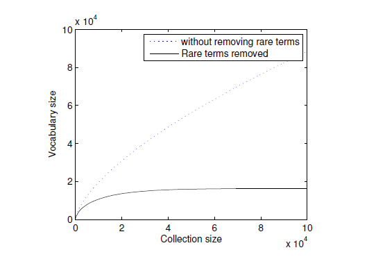

```python
os.chdir(r'U:\My Pictures')

print('Figure 2 unique Vocabulary size(y-axis) vs overall size of text corpus (x-axis) figure from [1]')

from IPython.display import Image
Image(filename='Vocab to text corpus size graph.png')
```

```python
#Print out tables of NMF code
os.chdir(r'\\nsq024vs\u8\aczd087\MyDocs\Data science masters\IN3061 INM430 Prin of Data Sc\Coursework\results')

pd.read_excel('NMF topic modelling grid search summary table.xlsx')
```

|  | No of Topics | No of topics coherent (Human qualitative assessment) of bottom 20 PMI values | Average PMI score of bottom 20 values |
| --- | --- | --- | --- |
| 0 | 50 | 0.90 | 0.80 |
| 1 | 200 | 0.95 | 0.79 |
| 2 | 300 | 0.75 | 0.71 |

## Generating NMF model topic lists for each document corpus.

NMF model generated topics used to classify each headline string for the following 01-Jan to 30-Jun time periods:

- 2009
- 2012
- 2014

This was done repeatedly with the same script below which generated an excel spreasheet of each topic, its PMI score with the list being ranks from lowest to highest PMI score.

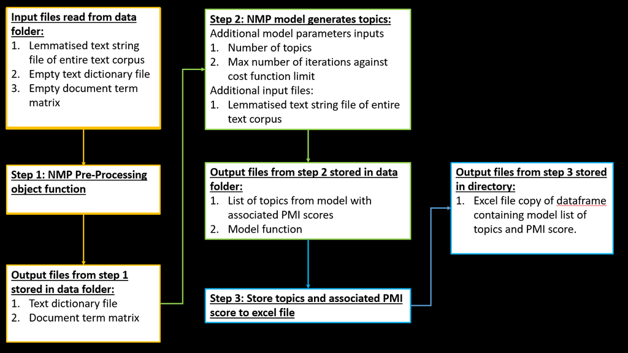

```python
os.chdir(r'\\nsq024vs\u8\aczd087\Desktop')

from IPython.display import Image
Image(filename='NMP_PFD.png')
```

```python
#Changing directory for file operation

#PLEASE READ THE READ ME FILE PRIOR TO RUNNING ANY OF THESE CELLS.

os.chdir(r'\\nsq024vs\u8\aczd087\MyDocs\Data science masters\IN3061 INM430 Prin of Data Sc\Coursework')
```

```python
#2009 NMF model generation

NMF_Pre_process('data/News_2009_janjun_proc_df.txt','data/doc_term_mat_abcnews.txt','data/vocab.txt',10000)

NMF_training_model('data/doc_term_mat_abcnews.txt','data/vocab.txt',150,200)

NMF_Printout_topics('data/doc_term_mat_abcnews.txt','data/vocab.txt','seanmf_results/W.txt','News_2009_janjun_200topics.xlsx')
```

```python
#2012 NMF model generation

#os.chdir(r'C:\Users\niall\Dropbox\Data science masters\IN3061 INM430 Prin of Data Sc\Coursework\Documentation')

NMF_Pre_process('data/News_2012_janjun_proc_df.txt','data/doc_term_mat_abcnews.txt','data/vocab.txt',10000)

NMF_training_model('data/doc_term_mat_abcnews.txt','data/vocab.txt',150,200)

NMF_Printout_topics('data/doc_term_mat_abcnews.txt','data/vocab.txt','seanmf_results/W.txt','News_2012_janjun_200topics.xlsx')
```

```python
NMF_Printout_topics('data/doc_term_mat_abcnews.txt','data/vocab.txt','seanmf_results/W.txt','News_2012_janjun_200topics.xlsx')
```

```python
#2014 NMF model generation

#os.chdir(r'C:\Users\niall\Dropbox\Data science masters\IN3061 INM430 Prin of Data Sc\Coursework\Documentation')
NMF_Pre_process('data/News_2014_janjun_proc_df.txt','data/doc_term_mat_abcnews.txt','data/vocab.txt',10000)

NMF_training_model('data/doc_term_mat_abcnews.txt','data/vocab.txt',150,200)

NMF_Printout_topics('data/doc_term_mat_abcnews.txt','data/vocab.txt','seanmf_results/W.txt','News_2014_janjun_200topicsxlsx')
```

```python
NMF_Printout_topics('data/doc_term_mat_abcnews.txt','data/vocab.txt','seanmf_results/W.txt','News_2014_janjun_200topicsxlsx')
```

## Topic assignment of headlines documents for analysis

Once the sampling of the topic modelling of the three time points was complete topic assignment to each document was performed. The major assumption made for this approach was that only one topic was assigned to each document. This assumption was justified being that the average size of the document being <80 characters the odds of more than one major topic being present was low. The methodology for assigning a topic to each document was the following:

1. All topics keywords are cross checked against the words present in the document string.
2. If a topic keyword is present in the topic string its associated PMI score for that topic is cumulatively assigned to that topic for that document for each keyword present.
3. The topic assigned to that document is then the determined by the highest cumalitive PMI score.

The justification for this approach is that, with only one topic being assigned to each document the topic which has the highest number of keywords with the greatest likelihood of having other keywords within that topic being present(which is what PMI estimates) in the document is the most likely topic of that document. Once the initial topic classification was complete these topics where compared against the aggregate topic labels to further simplify and reduce down the number of topics present in the document classification dataset. Any document that could not be classified by this approach was discarded from further analysis.

```python
#Loading up dataframes for assigning topics ot different time period

os.chdir(r'\\nsq024vs\u8\aczd087\MyDocs\Data science masters\IN3061 INM430 Prin of Data Sc\Coursework')

#Reading in NMF files of topics from server
topics_2009_janjun=pd.read_excel('News_2009_janjun_200topics.xlsx')
topics_2012_janjun=pd.read_excel('News_2012_janjun_200topics.xlsx')
topics_2014_janjun=pd.read_excel('News_2014_janjun_200topics.xlsx')
```

### Object oriented programs used in topic classification

```python
#Assigning different topics to different news headlines in 2009 jan to jun dataframe based on maximum liklikhood principle

from collections import defaultdict

#Code to assign different topics to each string in the dataset based on keywords present in the string.

def contains_word(s, w): #Combining split strings
    return (' ' + w + ' ') in (' ' + s + ' ')

def document_topic_classifier(df_headlines,df_topic_list,Topic_agg=0):

    topic_blk=[] #Initialising blank list where topic will be stored.
    temp_str='No topic assignment'
    temp_str2='Short_topic_aggregated'


    topics_list=[] #Splitting dataframe string in to words to iterate through

    for idx, vals in df_topic_list.Topic_string.iteritems():
        topics_list.append(vals)

    topic_year_split_list=[]

    for vals in topics_list: #iterating through each topic spliting string to iterate through against headline
        ar_temp=0
        ar_temp=vals.split()
        topic_year_split_list.append(ar_temp)

    for idx,vals in df_headlines.headline_text.iteritems(): #iterating through each index headlines

        #print(f'headlines is: {vals}')
        blk_dict=defaultdict(int) #Initialing default dictionary to store data in
        ar_temp=0
        for topics in topic_year_split_list: #For loop iterating through each topic
            #iterating through each topic
            key=0
            key=' '.join(topics)

            for words in topics: #iterating through each word in topic

                if contains_word(vals,words)==True: #comparing words in topic to words in headline if present
                    ar_temp2=0
                    ar_temp2=df_topic_list.loc[df_topic_list['Topic_string'] == key, 'PMI_value'] #Acquiring PMI value from topic dataframe
                    #print(f'key is:{key}')
                    blk_dict[key]+=float(ar_temp2.item()) #Assigning PMI value for word to dataframe

                    #print(f'dictionary is {blk_dict}')
                    #If word is present topic value increases by one.


        if len(blk_dict)>0:

            ar_temp=max(blk_dict, key=blk_dict.get)   #Assign topic to maximum value pair

            #print(f'max value pair is {ar_temp}')
            topic_blk.append(ar_temp)
        else:
            topic_blk.append(temp_str)

    if Topic_agg==True:    #confirm topic aggregation

        final_blk=[]#Reassign topics of list to topic aggregation labels if true

        Agg_dict=pd.Series(df_topic_list.Short_topic_aggregated.values,index=df_topic_list.Topic_string).to_dict()#Creating dictoinary of topics and agg topic to iterate through

        for long_topics in topic_blk: #Iterating through block of long topics and comparing to unique key of values.

            if long_topics==temp_str: #No aggregation topic present still assign 'No topic assignment' for filtering of unclassified values at a later point.
                final_blk.append(temp_str)

            else: #If topic is classified proceed to iterate and compare long topic to shorten down aggregated topic.

                for key,value in Agg_dict.items():

                    if key == long_topics:
                                                #if key present in topic _blk append said value of key to final_blk
                        final_blk.append(value)

    else: #If topic aggregation not required move to return final value as final_blk

        final_blk=topic_blk

    return final_blk
```

### Topic classification programming section

Please find below the programmin outline of the topic classification for each document for the period of 01-Jan to 30-Jun for:

- 2009
- 2012
- 2014

```python
#2009 topic classification and topic modelling.
#Iterating through dataframe and classifying each document with topic list
topit=document_topic_classifier(News_2009_jan_jun,topics_2009_janjun,True)

topic_df_2009=pd.DataFrame(topit,columns=['topic_assigned'])

#Combining final dataframe together classfiers

final_df_topic_2009=pd.concat([News_2009_jan_jun,topic_df_2009],axis=1)

#removing Non classified document
final_df_topic_2009=final_df_topic_2009[final_df_topic_2009.topic_assigned!='No topic assignment']
final_df_topic_2009=final_df_topic_2009[final_df_topic_2009.topic_assigned!='?']
```

```python
#2012 topic classification and topic modelling.
#Iterating through dataframe and classifying each document with topic list
topit2012=document_topic_classifier(News_2012_jan_jun,topics_2012_janjun,True)

topic_df_2012=pd.DataFrame(topit2012,columns=['topic_assigned'])

#Combining final dataframe together classfiers

final_df_topic_2012=pd.concat([News_2012_jan_jun,topic_df_2012],axis=1)

#removing Non classified document
final_df_topic_2012=final_df_topic_2012[final_df_topic_2012.topic_assigned!='No topic assignment']
final_df_topic_2012=final_df_topic_2012[final_df_topic_2012.topic_assigned!='?']
```

```python
#2014 topic classification and topic modelling.
#Iterating through dataframe and classifying each document with topic list
topit2014=document_topic_classifier(News_2014_jan_jun,topics_2014_janjun,True)

topic_df_2014=pd.DataFrame(topit2014,columns=['topic_assigned'])

#Combining final dataframe together classfiers

final_df_topic_2014=pd.concat([News_2014_jan_jun,topic_df_2014],axis=1)

#removing Non classified document
final_df_topic_2014=final_df_topic_2014[final_df_topic_2014.topic_assigned!='No topic assignment']
final_df_topic_2014=final_df_topic_2014[final_df_topic_2014.topic_assigned!='?']
```

```python
final_df_topic_2014.head()
```

```python
#Saving final topic list to excel 2009
final_df_topic_2009.to_excel('Final_Topic_2009df.xlsx')
```

```python
#Saving final topic list to excel 2012
final_df_topic_2012.to_excel('Final_Topic_2012df.xlsx')
```

```python
#Saving final topic list to excel 2014
final_df_topic_2014.to_excel('Final_Topic_2014df.xlsx')
```

# Chi Squared analysis and topic/stock volatility visualisations of data

In this section Chi Squared analysis was performed on the datasets between the different years and against the different volatility labels to determine if there what type of association if any was present between these two data sets.

## Object Programs setup

Please find below the objects that where utilised in the analysis of each of these data sets.

```python
from scipy.stats import chi2_contingency

def chisq_of_df_cols(df, c1, c2):
    groupsizes = df.groupby([c1, c2]).size()
    ctsum = groupsizes.unstack(c1)
    # fillna(0) is necessary to remove any NAs which will cause exceptions
    return(chi2_contingency(ctsum.fillna(0)))

def general_BSH_ratios(df):

    cr1=df.DJIA_BuySellHoldLabels.value_counts()

    cr1_BHR=cr1.iloc[2]/cr1.iloc[0]
    cr1_SHR=cr1.iloc[1]/cr1.iloc[0]

    cr2=df.ASX_200_BuySellHoldLabels.value_counts()

    cr2_BHR=cr2.iloc[2]/cr2.iloc[0]
    cr2_SHR=cr2.iloc[1]/cr2.iloc[0]

    cr3=df.ASX_200_Fin_BSHLabels.value_counts()

    cr3_BHR=cr3.iloc[2]/cr3.iloc[0]
    cr3_SHR=cr3.iloc[1]/cr3.iloc[0]

    l_BHR=[cr1_BHR, cr2_BHR,cr3_BHR]

    l_SHR=[cr1_SHR, cr2_SHR,cr3_SHR]

    df_BSH_summary=pd.concat([cr1, cr2,cr3], axis=1)
    df_BSH_summary_list=df_BSH_summary.values.tolist()
    df_BSH_summary_list.append(l_BHR)
    df_BSH_summary_list.append(l_SHR)


    index_list=['B','H','S','BHR','SHR']

    col_names =['DJIA_BuySellHoldLabels','ASX_200_BuySellHoldLabels','ASX_200_Fin_BSHLabels']

    df_final_sum=pd.DataFrame(df_BSH_summary_list,
                          index=index_list,
                          columns=['DJIA_BuySellHoldLabels','ASX_200_BuySellHoldLabels','ASX_200_Fin_BSHLabels'])

    return df_final_sum


def generate_contigencyplot(drop_col_list,Gen_df_pre_drop,groupby_string,label_tr):
#Generate new pivot contigency table

    DJIA_2009_BSH=Gen_df_pre_drop.drop(drop_col_list,axis=1) #drop indexes from columns that are not being assessed
    count_temp=DJIA_2009_BSH.groupby(['topic_assigned',groupby_string]).count() #Count parameters from

    New_set=count_temp.reset_index().pivot('topic_assigned',groupby_string,'headline_text')
    New_set['Buy:Hold']=New_set['B']/New_set['H']
    New_set['Sell:Hold']=New_set['S']/New_set['H']

    #Generation of threshold markers to delineate categorical variables that are to be used as features
    New_set_mean_buy=New_set['B'].mean()
    New_set_mean_sell=New_set['S'].mean()
    New_set_mean_hold=New_set['H'].mean()

    New_set_mean_buy_hold_ratio=New_set_mean_buy/New_set_mean_hold
    New_set_mean_sell_hold_ratio=New_set_mean_sell/New_set_mean_hold

    #Generating general plot to observe all buy sell and hold signals for time period across all buy sell and hold quadrants

    ax=New_set.plot(kind='scatter',y='Buy:Hold',x='Sell:Hold',figsize=(20,10)) #threshold set at 0.5
    ax.axhline(New_set_mean_buy_hold_ratio,color='g',label='buy threshold')
    ax.axvline(New_set_mean_sell_hold_ratio,color='r',label='sell threshold')

    plt.text(New_set_mean_sell_hold_ratio+label_tr, #Label threshold inputted to ensure they can be realigned for different scalings of graph
             New_set_mean_buy_hold_ratio+label_tr,
             'Highly volatile',fontsize=12,
             bbox=dict(facecolor='orange', alpha=0.5))

    plt.text(New_set_mean_sell_hold_ratio-label_tr,
             New_set_mean_buy_hold_ratio+label_tr,
             'Buy signals',
             fontsize=12,
             bbox=dict(facecolor='green', alpha=0.5))

    plt.text(New_set_mean_sell_hold_ratio+label_tr,
             New_set_mean_buy_hold_ratio-label_tr,
             'Sell Signals',
             fontsize=12,
             bbox=dict(facecolor='red', alpha=0.5))

    plt.text(New_set_mean_sell_hold_ratio-label_tr,
             New_set_mean_buy_hold_ratio-label_tr,
             'Lower Volatility',
             fontsize=12,
             bbox=dict(facecolor='grey', alpha=0.5))
    plt.title('General buy,sell and hold plot',fontsize=12)
    plt.legend()
    fig1 = plt.gcf()
    #fig1.set_size_inches(11,8)
    fig1.savefig('temp_mainchart.png') #Saving plot to file

    plt.show()




    #Creating new arrays for dataset for visualising threshold data quadrants
    #High volatility labels  Chart generation
    BSH_HV_BVlabel=New_set.loc[(New_set['Buy:Hold']>=New_set_mean_buy_hold_ratio)&
                               (New_set['Sell:Hold']>=New_set_mean_sell_hold_ratio),
                               'Buy:Hold']
    BSH_HV_SVlabel=New_set.loc[(New_set['Buy:Hold']>=New_set_mean_buy_hold_ratio)&
                               (New_set['Sell:Hold']>=New_set_mean_sell_hold_ratio),
                               'Sell:Hold']

    fig, ax = plt.subplots(figsize=(20,10))
    ax.scatter(BSH_HV_SVlabel, BSH_HV_BVlabel,color='orange')

    for i,vals in enumerate(BSH_HV_BVlabel.index): #Annotating and labelling all points in the chart with news topics
        ax.text(BSH_HV_SVlabel.iloc[i],
                BSH_HV_BVlabel.iloc[i],
                vals)

    fig2 = plt.gcf() #Saving plot to file
    #fig1.set_size_inches(11,8)
    fig2.savefig('high_volatility_chart.png')

    plt.show()


    #Low volatility labels  Chart generation
    BSH_LV_BVlabel=New_set.loc[(New_set['Buy:Hold']<=New_set_mean_buy_hold_ratio)&
                               (New_set['Sell:Hold']<=New_set_mean_sell_hold_ratio),
                               'Buy:Hold']

    BSH_LV_SVlabel=New_set.loc[(New_set['Buy:Hold']<=New_set_mean_buy_hold_ratio)&
                               (New_set['Sell:Hold']<=New_set_mean_sell_hold_ratio),
                               'Sell:Hold']

    fig, ax = plt.subplots(figsize=(20,10))
    ax.scatter(BSH_LV_SVlabel, BSH_LV_BVlabel,color='grey')

    for i,vals in enumerate(BSH_LV_BVlabel.index):
        ax.text(BSH_LV_SVlabel.iloc[i],
                BSH_LV_BVlabel.iloc[i],
                vals)


    fig3 = plt.gcf() #Saving plot to file
    #fig1.set_size_inches(11,8)
    fig3.savefig('low_volatility_chart.png')
    plt.show()


    #Buy Signals Chart generation
    BSH_BS_BVlabel=New_set.loc[(New_set['Buy:Hold']>New_set_mean_buy_hold_ratio)&
                               (New_set['Sell:Hold']<New_set_mean_sell_hold_ratio),
                               'Buy:Hold']
    BSH_BS_SVlabel=New_set.loc[(New_set['Buy:Hold']>New_set_mean_buy_hold_ratio)&
                               (New_set['Sell:Hold']<New_set_mean_sell_hold_ratio),
                               'Sell:Hold']

    fig, ax = plt.subplots(figsize=(20,10))
    ax.scatter(BSH_BS_SVlabel, BSH_BS_BVlabel,color='green')

    for i,vals in enumerate(BSH_BS_BVlabel.index):
        ax.text(BSH_BS_SVlabel.iloc[i],
                BSH_BS_BVlabel.iloc[i],
                vals)

    fig4 = plt.gcf()
    #fig1.set_size_inches(11,8)
    fig4.savefig('Buys_Signal_chart.png')
    plt.show()


    #Sell Signals Chart generation
    BSH_SS_BVlabel=New_set.loc[(New_set['Buy:Hold']<New_set_mean_buy_hold_ratio)&
                               (New_set['Sell:Hold']>New_set_mean_sell_hold_ratio),
                               'Buy:Hold']
    BSH_SS_SVlabel=New_set.loc[(New_set['Buy:Hold']<New_set_mean_buy_hold_ratio)&
                               (New_set['Sell:Hold']>New_set_mean_sell_hold_ratio),
                               'Sell:Hold']

    fig, ax = plt.subplots(figsize=(20,10))
    ax.scatter(BSH_SS_SVlabel, BSH_SS_BVlabel,color='red')

    for i,vals in enumerate(BSH_SS_BVlabel.index):
        ax.text(BSH_SS_SVlabel.iloc[i],
                BSH_SS_BVlabel.iloc[i],
                vals)


    fig5 = plt.gcf()
    #fig1.set_size_inches(11,8)
    fig5.savefig('Sell_Signal_chart.png')

    plt.show()
```

## Importing of files for analysis

Please import the following files from directory folder prior to proceeding forwad

```python
#Load Topics into dataframe
os.chdir(r'\\nsq024vs\u8\aczd087\MyDocs\Data science masters\IN3061 INM430 Prin of Data Sc\Coursework\Financial news data')

topic_list_2009_BSH=pd.read_excel('Final_Topic_2009df.xlsx')
topic_list_2012_BSH=pd.read_excel('Final_Topic_2012df.xlsx')
topic_list_2014_BSH=pd.read_excel('Final_Topic_2014df.xlsx')
```

## Chi Squared analysis

Once this was complete and with a merging of the daily volatility discretized and document classification Chi squared tests of independence between the different news topics and stock volatility was performed across all the time series for the different indexes. The results from this analysis can be seen below. From this it could be deduced that there is some correlation between two. To visualise this and get a better understanding of this metric one has to go back to the initial question of what the objective of this model ‘predict buy,sell and hold signals in the stock exchange’. This continues in the next section.

```python
#2009 CHI squared results for data analysis

DJIA_2009_ChiSqr=chisq_of_df_cols(topic_list_2009_BSH, 'DJIA_BuySellHoldLabels', 'topic_assigned')

ASX_200_2009_ChiSqr=chisq_of_df_cols(topic_list_2009_BSH, 'ASX_200_BuySellHoldLabels', 'topic_assigned')

ASX_200_fin_2009_ChiSqr=chisq_of_df_cols(topic_list_2009_BSH, 'ASX_200_Fin_BSHLabels', 'topic_assigned')

print('CHI SQUARED RESULTS FOR 2009 STOCK INDICES VOLATILITY VERSUS NEWS TOPICS\n')
print(f'DJIA 2009 Chi sqr results are: {DJIA_2009_ChiSqr[:3]}')
print(f'ASX200 2009 Chi sqr results are: {ASX_200_2009_ChiSqr[:3]}')
print(f'ASX200 Financials 2009 Chi sqr results are: {ASX_200_fin_2009_ChiSqr[:3]}')

Summary_BSH_2009=general_BSH_ratios(topic_list_2009_BSH)

Summary_BSH_2009
```

```
CHI SQUARED RESULTS FOR 2009 STOCK INDICES VOLATILITY VERSUS NEWS TOPICS

DJIA 2009 Chi sqr results are: (589.3153451363676, 1.438166410625605e-32, 234)
ASX200 2009 Chi sqr results are: (320.31051156095856, 0.0001510537678896819, 234)
ASX200 Financials 2009 Chi sqr results are: (339.72863096782453, 7.472751443321046e-06, 234)
```

|  | DJIA_BuySellHoldLabels | ASX_200_BuySellHoldLabels | ASX_200_Fin_BSHLabels |
| --- | --- | --- | --- |
| B | 7434.000000 | 10079.000000 | 10663.000000 |
| H | 18903.000000 | 17099.000000 | 13642.000000 |
| S | 8530.000000 | 7689.000000 | 10562.000000 |
| BHR | 0.393271 | 0.449675 | 0.774227 |
| SHR | 0.451251 | 0.589450 | 0.781630 |

```python
#2012 CHI squared results for data analysis

DJIA_2012_ChiSqr=chisq_of_df_cols(topic_list_2012_BSH, 'DJIA_BuySellHoldLabels', 'topic_assigned')

ASX_200_2012_ChiSqr=chisq_of_df_cols(topic_list_2012_BSH, 'ASX_200_BuySellHoldLabels', 'topic_assigned')

ASX_200_fin_2012_ChiSqr=chisq_of_df_cols(topic_list_2012_BSH, 'ASX_200_Fin_BSHLabels', 'topic_assigned')

print('CHI SQUARED RESULTS FOR 2012 STOCK INDICES VOLATILITY VERSUS NEWS TOPICS\n')

print(f'DJIA 2009 Chi sqr results are: {DJIA_2012_ChiSqr[:3]}')
print(f'ASX200 2009 Chi sqr results are: {ASX_200_2012_ChiSqr[:3]}')
print(f'ASX200 Financials 2009 Chi sqr results are: {ASX_200_fin_2012_ChiSqr[:3]}')

Summary_BSH_2012=general_BSH_ratios(topic_list_2012_BSH)

Summary_BSH_2012
```

```
CHI SQUARED RESULTS FOR 2012 STOCK INDICES VOLATILITY VERSUS NEWS TOPICS

DJIA 2009 Chi sqr results are: (403.3300621767073, 5.224017354893297e-21, 170)
ASX200 2009 Chi sqr results are: (261.1793941297389, 8.59583515379856e-06, 170)
ASX200 Financials 2009 Chi sqr results are: (270.8761269671875, 1.3609996340591645e-06, 170)
```

|  | DJIA_BuySellHoldLabels | ASX_200_BuySellHoldLabels | ASX_200_Fin_BSHLabels |
| --- | --- | --- | --- |
| B | 32076.000000 | 29531.000000 | 30401.000000 |
| H | 2949.000000 | 4201.000000 | 4025.000000 |
| S | 2779.000000 | 3996.000000 | 3302.000000 |
| BHR | 0.086638 | 0.135315 | 0.108615 |
| SHR | 0.091938 | 0.142257 | 0.132397 |

```python
#2014 CHI squared results for data analysis

DJIA_2014_ChiSqr=chisq_of_df_cols(topic_list_2014_BSH, 'DJIA_BuySellHoldLabels', 'topic_assigned')

ASX_200_2014_ChiSqr=chisq_of_df_cols(topic_list_2014_BSH, 'ASX_200_BuySellHoldLabels', 'topic_assigned')

ASX_200_fin_2014_ChiSqr=chisq_of_df_cols(topic_list_2014_BSH, 'ASX_200_Fin_BSHLabels', 'topic_assigned')

print('CHI SQUARED RESULTS FOR 2014 STOCK INDICES VOLATILITY VERSUS NEWS TOPICS\n')

print(f'DJIA 2014 Chi sqr results are: {DJIA_2014_ChiSqr[:3]}')
print(f'ASX200 2014 Chi sqr results are: {ASX_200_2014_ChiSqr[:3]}')
print(f'ASX200 Financials 2014 Chi sqr results are: {ASX_200_fin_2014_ChiSqr[:3]}')

Summary_BSH_2014=general_BSH_ratios(topic_list_2014_BSH)

Summary_BSH_2014
```

```
CHI SQUARED RESULTS FOR 2014 STOCK INDICES VOLATILITY VERSUS NEWS TOPICS

DJIA 2014 Chi sqr results are: (351.5464226825413, 1.9763725522110463e-10, 200)
ASX200 2014 Chi sqr results are: (311.66518063873065, 7.110989491679819e-07, 200)
ASX200 Financials 2014 Chi sqr results are: (399.2490988392725, 2.2324176301080086e-15, 200)
```

|  | DJIA_BuySellHoldLabels | ASX_200_BuySellHoldLabels | ASX_200_Fin_BSHLabels |
| --- | --- | --- | --- |
| B | 33758.000000 | 33214.000000 | 33444.000000 |
| H | 2855.000000 | 2838.000000 | 2569.000000 |
| S | 1817.000000 | 2378.000000 | 2417.000000 |
| BHR | 0.053824 | 0.071596 | 0.072270 |
| SHR | 0.084573 | 0.085446 | 0.076815 |

## Topic / stock volatility visualisations of data

From EDA it already know what the average distribution of buy, sell and hold signals are across the volatility time series for each index. Hence with this in mind it is valuable to know specific topics in the news which have buy, sell and hold signals which are a-typical and not in line with this distribution specifically parameters that have a greater frequency of buy and sell signals as opposed to holding signals. As a result two additional features where generated to take this into account the ratio of buy and sell signals to hold. These features where then plotted as x and y coordinates on a linear scale which was divided into four quadrants(See figures below).

### 2009 Time period

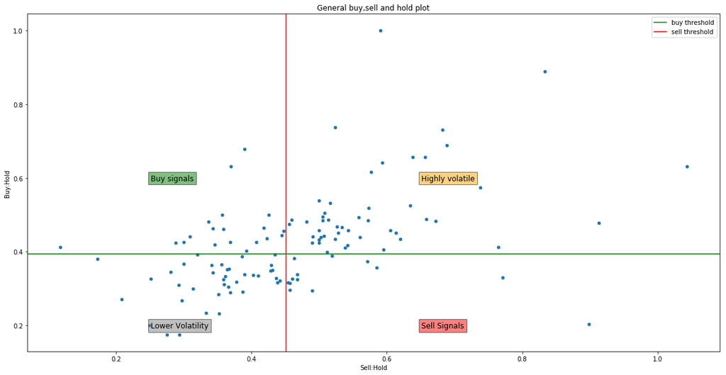

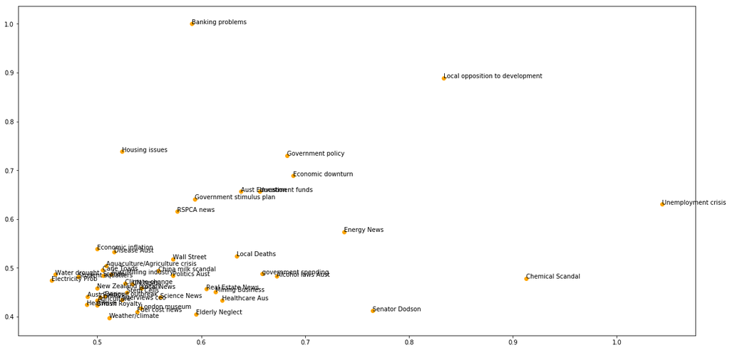

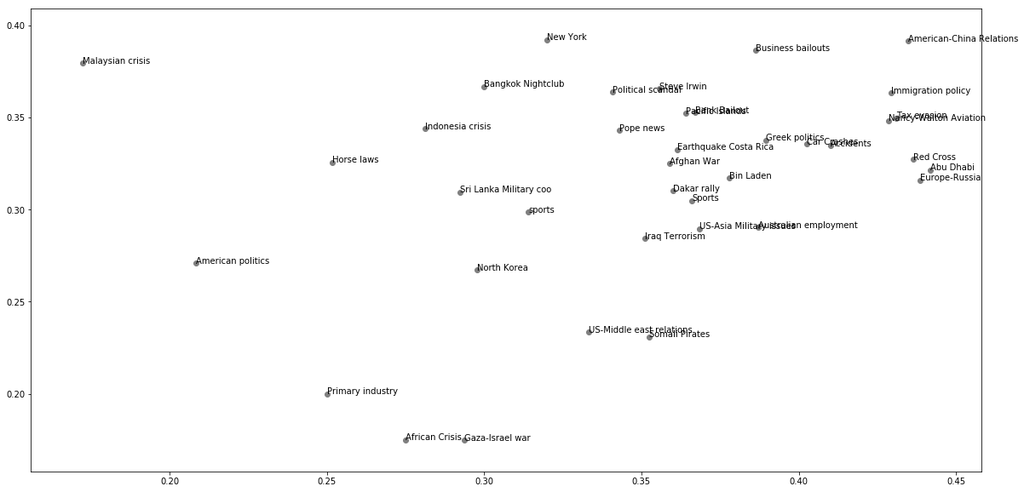

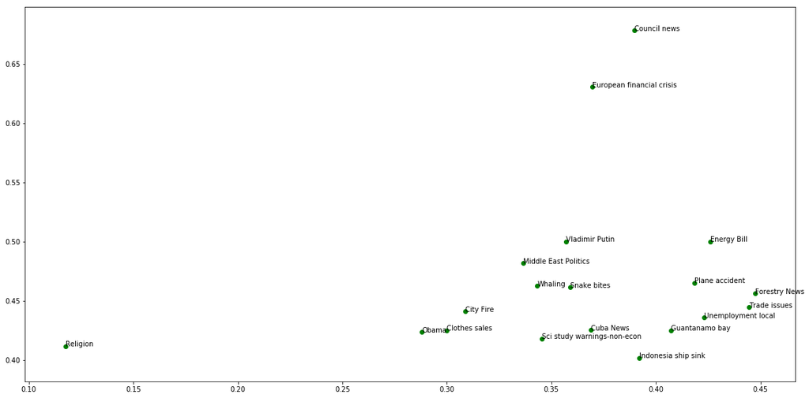

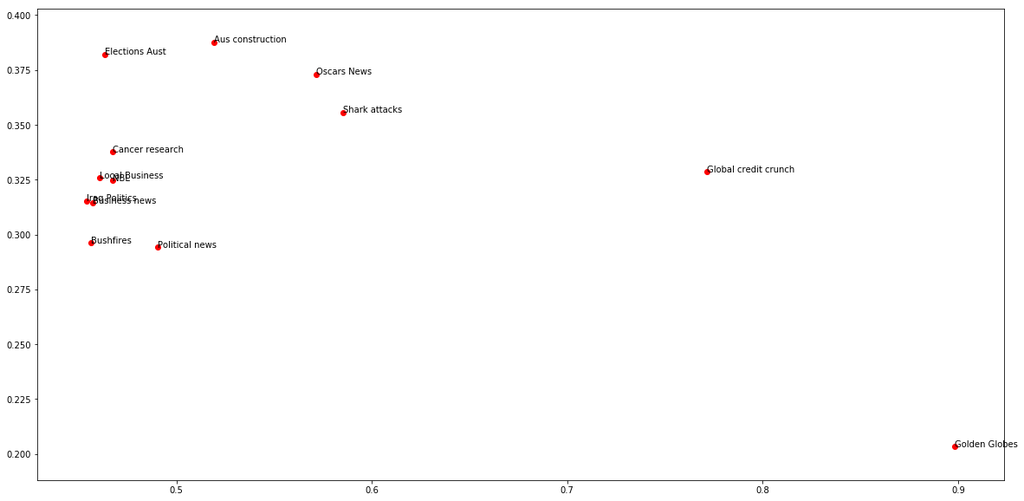

```python
#DJIA 2009 contigency plots

figcheck=generate_contigencyplot(['ASX_200_BuySellHoldLabels','ASX_200_Fin_BSHLabels','Date'],
                            topic_list_2009_BSH,
                            'DJIA_BuySellHoldLabels',0.2)
```

```python
figcheck.figure
plt.show()
```

[output not shown]

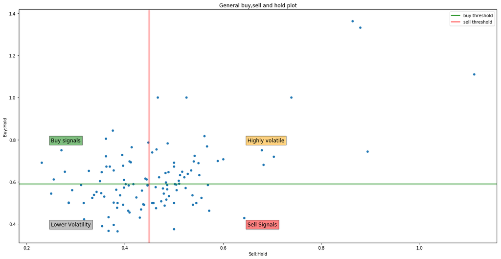

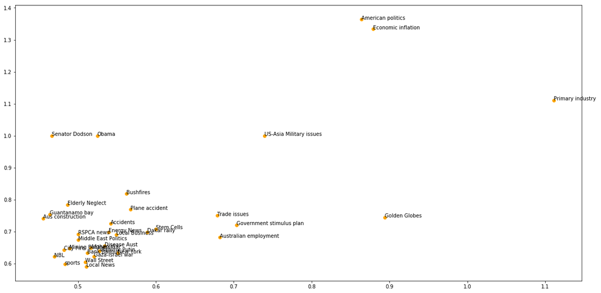

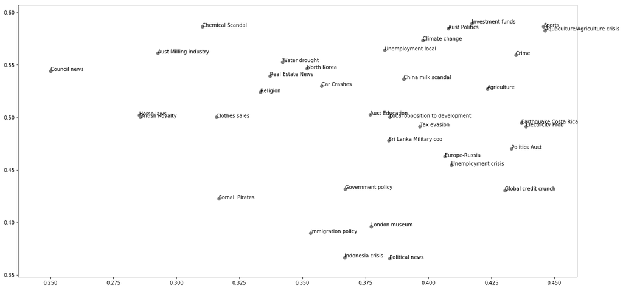

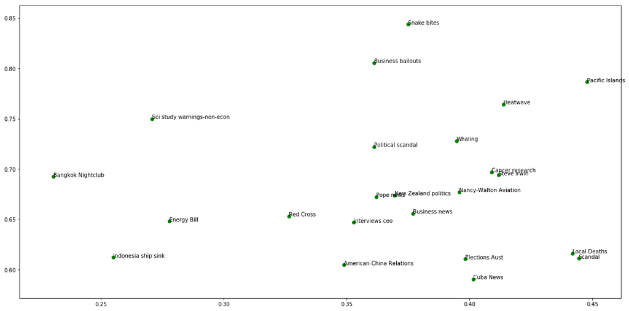

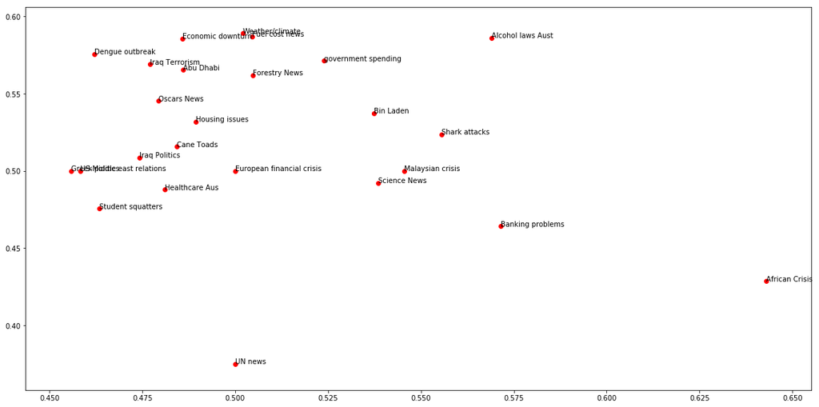

```python
#ASX200 2009 contigency plots
generate_contigencyplot(['ASX_200_Fin_BSHLabels','DJIA_BuySellHoldLabels','Date'],
                        topic_list_2009_BSH,
                        'ASX_200_BuySellHoldLabels',0.2)
```

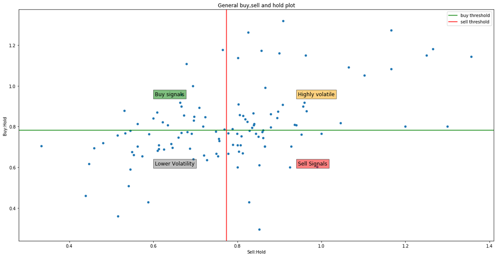

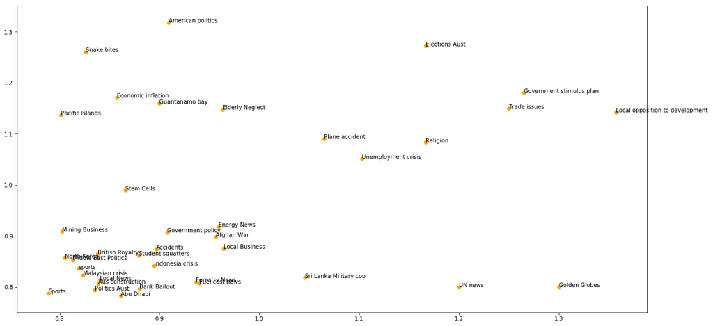

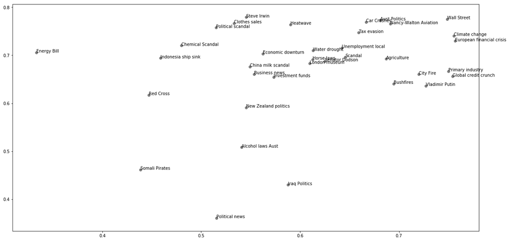

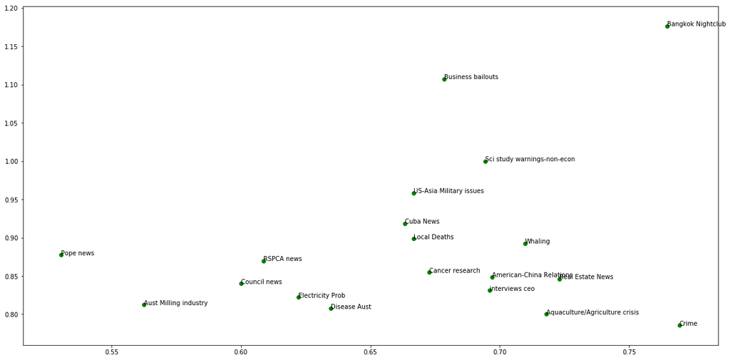

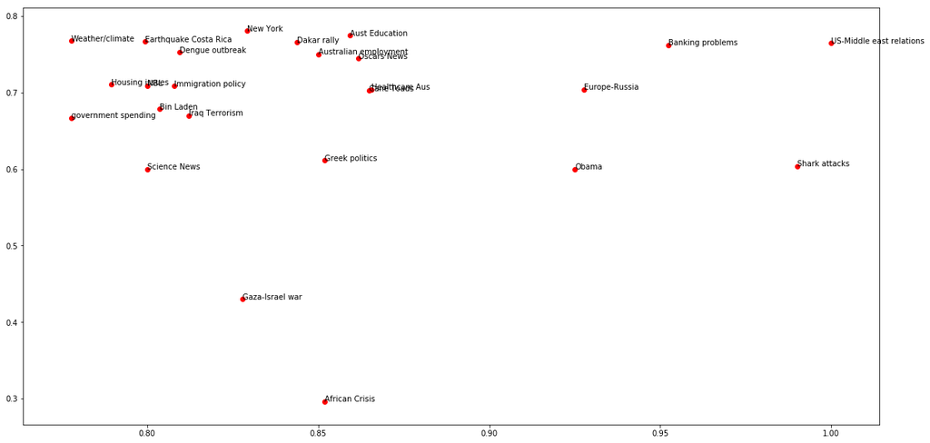

```python
#ASX200 Financials 2009 contigency plots

generate_contigencyplot(['ASX_200_BuySellHoldLabels','DJIA_BuySellHoldLabels','Date'],
                        topic_list_2009_BSH,
                        'ASX_200_Fin_BSHLabels',0.17)
```